# The Data Validation Cookbook

Mark P.J. van der Loo

2025-12-10

# Preface

This book is about checking data with the validate package for [R](https://www.r-project.org).

This version of the book was rendered with `validate` version 1.1.7. The latest release of `validate` can be installed from [CRAN](https://cran.r-project.org) as follows.

```r
install.packages("validate")
```

The purposes of this book include demonstrating the main tools and workflows of the `validate` package, giving examples of common data validation tasks, and showing how to analyze data validation results.

The book is organized as follows. Chapter 1 discusses the bare necessities to be able to follow the rest of the book. Chapters 2 to 5 form the ‘cookbook’ part of the book and discuss many different ways to check your data by example. Chapter 6 is devoted to deriving plausibility measures with the `validate` package. Chapters 7 and 8 treat working with validate in-depth. Chapter 10 discusses how to compare two or more versions of a dataset, possibly automated through the lumberjack package. The section with Bibliographical Notes lists some references and points out some literature for further reading.

## Prerequisites

Readers of this book are expected to have some knowledge of R. In particular, you should know how to import data into R and know a little about working with data frames and vectors.

## Citing this work

To cite the `validate` package please use the following citation.

> MPJ van der Loo and E de Jonge (2021). Data Validation Infrastructure for R. *Journal of Statistical Software*, 97(10) [paper](https://www.jstatsoft.org/article/view/v097i10).

To cite this cookbook, please use the following citation.

> MPJ van der Loo (2025) *The Data Validation Cookbook* version 1.1.7. [https://data-cleaning.github.io/validate](http://data-cleaning.github.io/validate/)

## Acknowledgements

This work was partially funded by European Grant Agreement 88287–NL-VALIDATION of the European Statistical System.

## Contributing

If you find a mistake, or have some suggestions, please file an issue or a pull request on the GitHub page of the package: https://github.com/data-cleaning/validate. If you do not have or want a GitHub account, you can contact the author via the e-mail address that is listed with the package.

## License

This work is licensed under [Creative Commons Attribution BY-NC 4.0 International License](https://creativecommons.org/licenses/by-nc/4.0/).

# 1 Introduction to validate

> Data Validation is an activity verifying whether or not a combination of values is a member of a set of acceptable combinations [(Di Zio et al , 2015)](https://www.markvanderloo.eu/files/share/zio2015methodology.pdf)

The validate package is intended to make checking your data easy, maintainable, and reproducible. It does this by allowing you to

- test data against a reusable set of data validation rules:
- investigate, summarise, and visualise data validation results;
- import and export rule sets from and to various formats;
- filter, select and otherwise manipulate data validation rules’;
- investigate, summarise, and visualise rule sets.

For advanced rule manipulation there is the validatetools package.

## 1.1 A quick example

Here’s an example demonstrating the typical workflow. We’ll use the built-in `cars` data set, which contains 50 cases of speed and stopping distances of cars.

```r
data(cars)
head(cars, 3)
```

```
##   speed dist
## 1     4    2
## 2     4   10
## 3     7    4
```

Validating data is all about checking whether a data set meets presumptions or expectations you have about it, and the validate package makes it easy for you to define those expectations. Let’s do a quick check on variables in the `cars` data set. We first load the package, and create a list of data quality demands with the `validator()` function.

```r
library(validate)
rules <- validator(speed >= 0
                 , dist >= 0
                 , speed/dist <= 1.5
                 , cor(speed, dist)>=0.2)
```

Here, the first three rules are record-wise checks: each record will yield one answer. In the last rule we check whether speed and distance are positively correlated this will yield a single `TRUE` or `FALSE` for the whole data set. We now confront the data with those rules and save the output into a variable called `out`.

```r
out   <- confront(cars, rules)
```

The easiest way to check the results is with `summary()`.

```r
summary(out)
```

```
##   name items passes fails nNA error warning              expression
## 1   V1    50     50     0   0 FALSE   FALSE     speed - 0 >= -1e-08
## 2   V2    50     50     0   0 FALSE   FALSE      dist - 0 >= -1e-08
## 3   V3    50     48     2   0 FALSE   FALSE       speed/dist <= 1.5
## 4   V4     1      1     0   0 FALSE   FALSE cor(speed, dist) >= 0.2
```

This returns a data frame with one line of information for each rule `V1`, `V2`, `V3` and `V4`. To be precise:

- How many data items were checked against each rule.
- How many items passed, failed or resulted in `NA`.
- Whether the check resulted in an error (could not be performed) or gave an warning.
- The expression that was actually evaluated to perform the check.

The same information can be summarized graphically as follows .

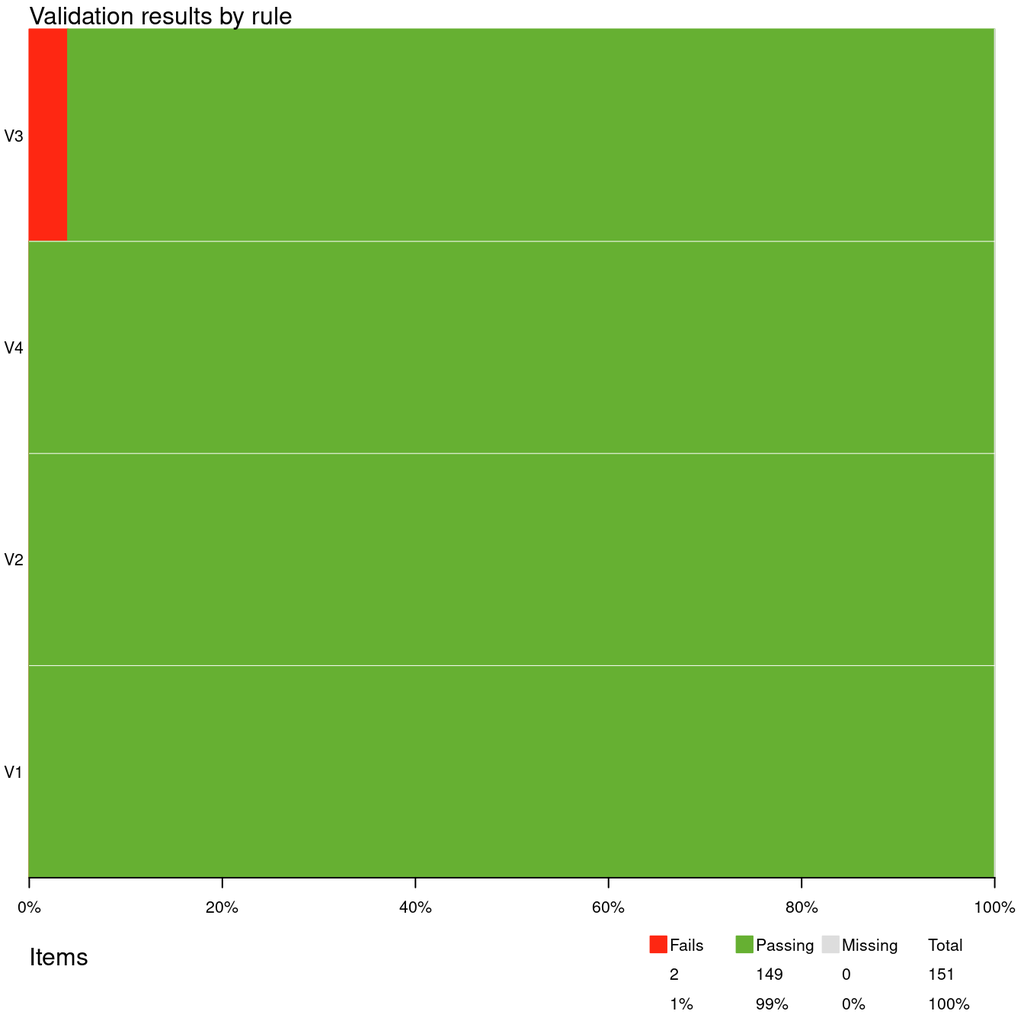

```r
plot(out)
```

In this plot each horizontal bar indicates the percentage of Failing, Passing, and Missing cases. The table in the legend lists the total number of Fails, Passes and Missings, summed over all checks. Here, we have 4 rules. The first three rules yield 50 results each, while the last rule yields a single result. Hence there are 151 validation results in total.

Using the function `violating` we can select the records that violate one or more rules. We select only the first three results because the last rule can not be interpreted record by record.

```r
violating(cars, out[1:3])
```

```
##   speed dist
## 1     4    2
## 3     7    4
```

We can extract all individual results using for example `as.data.frame`.

```r
df_out <- as.data.frame(out)
head(df_out, 3)
```

```
##   name value          expression
## 1   V1  TRUE speed - 0 >= -1e-08
## 2   V1  TRUE speed - 0 >= -1e-08
## 3   V1  TRUE speed - 0 >= -1e-08
```

We see that in record `1`, rule `V1`, was satisfied (the result is `TRUE`), and that validate left a bit of slack when executing the rule, to avoid false negatives caused by machine rounding issues.

Summarizing, the basic workflow in `validate` is to create a rule set, confront a data set with the rules in the rule set, and then analyze or use the results further. To understand which checks you can perform with `validate` you only need to remember the following.

> Any R expression that results in a `logical` is accepted by `validate` as a validation rule.

You are now ready to start validating your data, and navigate Chapters 3-5 to learn how to define specific types of checks. Chapter~7, discusses more details about working with `validate`.

# 2 Variable checks

Variable checks are checks that can be performed on a field-by-field basis. An example is checking that a variable called `Age` is nonnegative, or of integer type. Variable checks are among the simplest checks.

**Data**

In this section we will use the `SBS2000` dataset, that is included with `validate`.

```r
library(validate)
data(SBS2000)
head(SBS2000, 3)
```

```
##      id size incl.prob staff turnover other.rev total.rev staff.costs
## 1 RET01  sc0      0.02    75       NA        NA      1130          NA
## 2 RET02  sc3      0.14     9     1607        NA      1607         131
## 3 RET03  sc3      0.14    NA     6886       -33      6919         324
##   total.costs profit vat
## 1       18915  20045  NA
## 2        1544     63  NA
## 3        6493    426  NA
```

See `?SBS2000` for a description.

## 2.1 Variable type

In `R`, one can test the type of a variable using built-in functions such as `is.numeric` or `is.character`.

```r
is.character("hihi")
```

```
## [1] TRUE
```

```r
is.character(3)
```

```
## [1] FALSE
```

In `validate`, any function starting with `is.` (‘is’ followed by a dot) is considered a validation function.

```r
rules <- validator(
    is.character(size)
  , is.numeric(turnover)
)
out <- confront(SBS2000, rules)
summary(out)
```

```
##   name items passes fails nNA error warning           expression
## 1   V1     1      0     1   0 FALSE   FALSE   is.character(size)
## 2   V2     1      1     0   0 FALSE   FALSE is.numeric(turnover)
```

We see that each rule checks a single item, namely one column of data. The first rule is violated (it is in fact a `factor` variable). The second rule is satisfied.

## 2.2 Missingness

Use R’s standard `is.na()` to check missing items in individual variables. Negate it to check that values are available.

```r
rule <- validator(
   !is.na(turnover)
 , !is.na(other.rev)
 , !is.na(profit)
)
out <- confront(SBS2000, rule)
summary(out)
```

```
##   name items passes fails nNA error warning        expression
## 1   V1    60     56     4   0 FALSE   FALSE  !is.na(turnover)
## 2   V2    60     24    36   0 FALSE   FALSE !is.na(other.rev)
## 3   V3    60     55     5   0 FALSE   FALSE    !is.na(profit)
```

We see that in 4 cases the variable `turnover` is missing, while `other.rev` and `profit` are missing respectively in 36 and 5 occasions.

To demand that all items must be present or absent for a certain variable, use R’s quantifiers: `any()` or `all()`, possibly negated.

```r
rules <- validator(
    !any(is.na(incl.prob))
    , all(is.na(vat)) )
out <- confront(SBS2000, rules)
summary(out)
```

```
##   name items passes fails nNA error warning             expression
## 1   V1     1      1     0   0 FALSE   FALSE !any(is.na(incl.prob))
## 2   V2     1      0     1   0 FALSE   FALSE        all(is.na(vat))
```

- To check whether records or parts thereof are completed, see 4.1.
- To check whether records are available at all, see 3.3.

## 2.3 Field length

The number of characters in text fields can be tested using either R’s standard `nchar()` function, or with the convenience function `field_length`.

```r
rules <- validator(
   nchar(as.character(size)) >= 2
 , field_length(id, n=5)
 , field_length(size, min=2, max=3)
)
out <- confront(SBS2000, rules)
summary(out)
```

```
##   name items passes fails nNA error warning
## 1   V1    60     60     0   0 FALSE   FALSE
## 2   V2    60     60     0   0 FALSE   FALSE
## 3   V3    60     60     0   0 FALSE   FALSE
##                             expression
## 1       nchar(as.character(size)) >= 2
## 2              field_length(id, n = 5)
## 3 field_length(size, min = 2, max = 3)
```

One advantage of `check_field_length` is that its argument is converted to character (recall that `size` is a `factor` variable). The function `field_length` can be used to either test for exact field lengths or to check whether the number of characters is within a certain range.

The field length is measured as the number of [code points](https://en.wikipedia.org/wiki/Code_point). Use `type="width"` to measure the printed width (nr of columns) or `type="bytes"` to count the number of bytes.

## 2.4 Format of numeric fields

For numbers that are stored in `character` type, there is a convenience function called `number_format()` that accepts a variable name and a format specification.

```r
dat <- data.frame(x = c("2.54","2.66","8.142","23.53"))
```

To check that the numbers are formatted with one figure before, and two figures after the decimal point, we perform the following check.

```r
rule <- validator( number_format(x, format="d.dd"))
values(confront(dat, rule))
```

```
##         V1
## [1,]  TRUE
## [2,]  TRUE
## [3,] FALSE
## [4,] FALSE
```

Here, the specification `format="d.dd"` describes the allowed numeric formats. In this specification the `"d"` stands for a digit, any other character except the asterisk (`*`) stands for itself. The asterisk is interpreted as ‘zero or more digits’. Here are some examples of how to define number formats.

| format | match | non-match |
| --- | --- | --- |
| `0.dddd` | `"0.4321"` | `"0.123"`,`"1.4563"` |
| `d.ddEdd` | `"3.14E00"` | `"31.14E00"` |
| `d.*Edd` | `"0.314E01"`,`"3.1415297E00"` | `"3.1415230"` |
| `d.dd*` | `"1.23"`, `"1.234"`,$\ldots$ | `"1.2"` |

The last example shows how to check for a minimal number of digits behind the decimal point.

There are special arguments to check the number of decimal figures after the decimal separator.

```r
x <- c("12.123","123.12345")
number_format(x, min_dig=4)
```

```
## [1] FALSE  TRUE
```

```r
number_format(x, max_dig=3)
```

```
## [1]  TRUE FALSE
```

```r
number_format(x, min_dig=2, max_dig=4)
```

```
## [1]  TRUE FALSE
```

```r
number_format(x, min_dig=2, max_dig=10)
```

```
## [1] TRUE TRUE
```

```r
# specify the decimal separator.
number_format("12,123", min_dig=2, dec=",")
```

```
## [1] TRUE
```

The arguments `min_dig`, `max_dig` and `dec` are ignored when `format` is specified.

This function is convenient only for fairly simple number formats. Generic pattern matching in strings is discussed in the next section.

## 2.5 General field format

A simple way to check for more general format is to use globbing patterns. In such patterns, the asterisk wildcard character (`*`) is interpreted as ‘zero or more characters’ and the question mark (`?`) is interpreted as ‘any character’.

For example, to check that the `id` variable in `SBS2000` starts with `"RET"`, and that the `size` variable has consists of `"sc"` followed by precisely one character, we can do the following.

```r
rule <- validator(field_format(id, "RET*")
                , field_format(size, "sc?" ))
out  <- confront(SBS2000, rule)
summary(out)
```

```
##   name items passes fails nNA error warning                expression
## 1   V1    60     60     0   0 FALSE   FALSE  field_format(id, "RET*")
## 2   V2    60     60     0   0 FALSE   FALSE field_format(size, "sc?")
```

Here, the globbing pattern `"RET*"` is understood as ’a string starting with `"RET"`, followed by zero or more characters. The pattern `"sc?"` means ’a string starting with `"sc"`, followed by a single character.

The most general way to check whether a field conforms to a pattern is to use a [regular expression](https://en.wikipedia.org/wiki/Regular_expression). The treatment of regular expressions is out of scope for this book, but we will give a few examples. A good introduction to regular expressions is given by

> J. Friedl (2006) *Mastering regular expressions.* O’Reilly Media.

In `validate` one can use `grepl` or `field_format`, with the argument `type="regex"`

```r
rule <- validator(
          grepl("^sc[0-9]$", size)
        , field_format(id, "^RET\\d{2}$" , type="regex") )
summary(confront(SBS2000, rule))
```

```
##   name items passes fails nNA error warning
## 1   V1    60     60     0   0 FALSE   FALSE
## 2   V2    60     60     0   0 FALSE   FALSE
##                                          expression
## 1                          grepl("^sc[0-9]$", size)
## 2 field_format(id, "^RET\\\\d{2}$", type = "regex")
```

Here, the expression `"^sc[0-9]$"` is a regular expression that should be read as: the string starts (`"^"`) with `"sc"`, is followed by a number between 0 and 9 (`"[0-9]"`) and then ends (`"$"`). The regular expression `"^RET\\{d}2"` indicates that a string must start (`"^"`) with `"RET"`, followed by two digits (`"\\d{2}"`), after which the string must end (`"$"`).

Globbing patterns are easier to develop and easier to understand than regular expressions, while regular expressions offer far more flexibility but are harder to read. Complex and long regular expressions may have subtle matching behaviour that is not immediately obvious to inexperienced users. It is therefore advisable to test regular expressions with a small dataset representing realistic cases that contains both matches and non-matches. As a rule of thumb we would advise to use globbing patterns unless those offer insufficient flexibility.

## 2.6 Numeric ranges

Numerical variables may have natural limits from below and/or above. For one-sided ranges, you can use the standard comparison operators.

```r
rules <- validator(TO = turnover >= 0
                 , TC = total.costs >= 0)
```

If a variable is bounded both from above and below one can use two rules, or use the convenience function `in_range`.

```r
rules <- rules +
  validator(PR = in_range(incl.prob, min=0, max=1))
```

By default, `in_range` includes the boundaries of the range, so the above rule is equivalent to `incl.prob >= 0` and `incl.prob <= 1`.

```r
out <- confront(SBS2000, rules, lin.ineq.eps=0)
```

Here we set `lin.ineq.eps=0` to keep `validate` from building in a margin for machine rounding errors.

```r
summary(out)
```

```
##   name items passes fails nNA error warning
## 1   TO    60     56     0   4 FALSE   FALSE
## 2   TC    60     55     0   5 FALSE   FALSE
## 3   PR    60     60     0   0 FALSE   FALSE
##                              expression
## 1                         turnover >= 0
## 2                      total.costs >= 0
## 3 in_range(incl.prob, min = 0, max = 1)
```

For numeric ranges it is often a better idea to work with inclusive inequalities ($\leq$, $\geq$) than with strict inequalities ($<$, $>$). Take as an example the strict inequality demand `income > 0`. This means that *any* income larger than zero is acceptable, including numbers such as $0.01$, $0.000001$ and $10^{-\textrm{Googol}}$. In practice there is almost always a natural minimal acceptable value that is usually dictated by the unit of measurement. For example, if we measure income in whole Euros, a better demand would be `income >= 1`.

## 2.7 Ranges for times and periods

For objects of class `Date` and objects of class `POSIXct` one can use comparison operators and `in_range` in the same way as for numerical data. The `in_range` function has a convenience feature for period data that is coded in character data, as in `"2018Q1"` for quarterly data.

We first generate some example data.

```r
period = sprintf("2018Q%d", 1:4)
period
```

```
## [1] "2018Q1" "2018Q2" "2018Q3" "2018Q4"
```

The `in_range` function is capable of recognizing certain date or period formats.

```r
in_range(period, min="2017Q2", max = "2018Q2")
```

```
## [1]  TRUE  TRUE FALSE FALSE
```

It is possible to specify your own date-time format using `strftime` notation. See `?in_range` and `?strptime` for specifications.

## 2.8 Code lists

A code list is a set of values that a variable is allowed to assume. For small code lists, one can use the `%in%` operator.

```r
rule <- validator(size %in% c("sc0","sc1","sc2","sc3"))
out  <- confront(SBS2000, rule)
summary(out)
```

```
##   name items passes fails nNA error warning
## 1   V1    60     60     0   0 FALSE   FALSE
##                                 expression
## 1 size %vin% c("sc0", "sc1", "sc2", "sc3")
```

Notice that `validate` replaces `%in%` with `%vin%`. The reason is that `%vin%` has more consistent behavior in the case of missing data. In particular,

```r
c(1, 3, NA) %in% c(1,2)
```

```
## [1]  TRUE FALSE FALSE
```

```r
c(1, 3, NA) %vin% c(1,2)
```

```
## [1]  TRUE FALSE    NA
```

For longer code lists it is convenient to refer to an externally provided list. There are two ways of doing this: reading the list in the right-hand-size of `%in%`, or passing a code list to `confront` as reference data.

Suppose we have a file called `codelist.csv` with a column `code`. We can define a rule as follows.

```r
rule <- validator(
  x %in% read.csv("codelist.csv")$code
)
## Or, equivalently
rule <- validator(
  valid_codes := read.csv("codelist.csv")$code
  , x %in% valid_codes
)
```

The disadvantage is that the rule now depends on a path that may or may not be available at runtime.

The second option is to assume that a variable, say `valid_codes` exists at runtime, and pass this with `confront`.

```r
codelist <- c("sc0","sc1","sc2","sc3")
rule <- validator(size %in% valid_codes)
# pass the codelist
out <- confront(SBS2000, rule
              , ref=list(valid_codes=codelist))
summary(out)
```

```
##   name items passes fails nNA error warning             expression
## 1   V1    60     60     0   0 FALSE   FALSE size %vin% valid_codes
```

This way, (very) large code lists can be used, but note that it does require a ‘contract’ between variable names used in the rule set and variables passed as reference data.

# 3 Availability and uniqueness

In this Chapter it is demonstrated how to check whether records are available and/or complete with respect to a set of keys, and whether they are unique. The checks described here are typically useful for data in ‘long’ format, where one column holds a value and all the other columns identify the value.

- To test for missing values in individual variables, see also 2.2.
- To check whether records or parts thereof are completed, see 4.1.

**Data**

In this Chapter the `samplonomy` dataset is used that comes with the `validate` package.

```r
library(validate)
data(samplonomy)
head(samplonomy, 3)
```

```
##   region freq period measure  value
## 1  Agria    A   2014     gdp 600000
## 2  Agria    A   2014  import 210000
## 3  Agria    A   2014  export 222000
```

## 3.1 Long data

The samplonomy data set is structured in ‘long form’. This means that each record has a single `value` column, and one or more columns containing character values that together describe what the value means.

```r
head(samplonomy,3)
```

```
##   region freq period measure  value
## 1  Agria    A   2014     gdp 600000
## 2  Agria    A   2014  import 210000
## 3  Agria    A   2014  export 222000
```

The data set contains several time series for multiple measures of the fictional country ‘Samplonia’. There are time series for several subregions of Samplonia.

Long format data is typically used as a transport format: it may be used to bulk-load data into SQL-based data base systems, or to transfer data between organisations in a unambiguous way.

Data in long form is in general much harder to check and process for statistical purpose than data in wide format, where each variable is stored in a separate column. The reason is that in long format relations between different variables are spread out across records, and those records are not necessarily ordered in any particular way prior to processing. This makes interpretation of validation fails intrinsically harder for long-form data than for wide-form data.

Naturally, we expect that the key combinations are unique, that all time series are gapless and complete, that the Balance of trade equals Export less Import everywhere, that district values add up to the provinces’, and that province values add up to the total of Samplonia. Finally, the quarterly time series must add up to the annual values.

## 3.2 Uniqueness

The function `is_unique()` checks whether combinations of variables (usually key variables) uniquely identify a record. It accepts any positive number of variable names and returns `FALSE` for each record that is duplicated with respect to the designated variables.

Here, we test whether region, period, and measure uniquely identify a value in the `samplonomy` data set.

```r
rule <- validator(is_unique(region, period, measure))
out <- confront(samplonomy, rule)
# showing 7 columns of output for readability
summary(out)[1:7]
```

```
##   name items passes fails nNA error warning
## 1   V1  1199   1197     2   0 FALSE   FALSE
```

There are 2 fails. After extracting the individual values for each record we can find the duplicated ones using a convenience function from `validate`.

```r
violating(samplonomy, out)
```

```
##       region freq period measure  value
## 870 Induston    Q 2018Q2  export 165900
## 871 Induston    Q 2018Q2  export 170000
```

There are a two subtleties to keep in mind when interpreting uniqueness. The first has to do with missing values, and the second has to do with grouping. To start with the missing value problem, take a look at the following two-record data frame.

```r
df <- data.frame(x = c(1,1), y = c("A",NA))
df
```

```
##   x    y
## 1 1    A
## 2 1 <NA>
```

How should we judge whether these two records are unique? A tempting option is to say the first record is unique, and to return `NA` for the second record since it contains a missing value: R has the habit of returning `NA` from calculations when an input value is `NA`. This choice is not invalid, but it would have consequences for determining whether the first record is unique as well. After all, it is possible to fill in a value in the missing field such that the two records are duplicates. Therefore, if one would return `NA` for the second record, the correct thing to do is to also return `NA` for the first record. In R, the choice is made to treat `NA` as an actual value when checking for duplicates or unique records (see `?duplicated` from base R). To see this inspect the following code and output.

```r
df <- data.frame(x=rep(1,3), y = c("A", NA, NA))
is_unique(df$x, df$y)
```

```
## [1]  TRUE FALSE FALSE
```

The second subtlety has to do with grouping. You may want to test whether a column is unique, given one or more other variables. It is tempting to think that this requires a split-apply-combine approach where the dataset is first split according to one or more grouping variables, check for uniqueness of the column in each group, and then combine the results. However, such an approach is not necessary as you can simply add the grouping variables to the list of variables that *together* must be unique.

As an example, consider the output of the following two approaches.

```r
# y is unique, given x. But not by itself
df <- data.frame(x=rep(letters[1:2],each=3), y=rep(1:3,2))

# the split-apply-combine approach
unsplit(tapply(df$y, df$x, is_unique), df$x)
```

```
## [1] TRUE TRUE TRUE TRUE TRUE TRUE
```

```r
# the combined approach
is_unique(df$x, df$y)
```

```
## [1] TRUE TRUE TRUE TRUE TRUE TRUE
```

## 3.3 Availability of records

This section is on testing for availability of whole records. Testing for individual missing values (NA), is treated in 2.2.

We wish to ensure that for each region, and each variable, the periods 2014, 2015, $\ldots$, 2019 are present. Using `contains_at_least` we can establish this.

```r
rule <- validator(
  contains_at_least(
      keys = data.frame(period = as.character(2014:2019))
    , by=list(region, measure) )
)
out <- confront(samplonomy, rule)
# showing 7 columns of output for readability
summary(out)[1:7]
```

```
##   name items passes fails nNA error warning
## 1   V1  1199   1170    29   0 FALSE   FALSE
```

The function `contains_at_least` splits the `samplonomy` dataset into blocks according to values of `region` and `measure`. Next, it checks that in each block the variable `period` contains at least the values 2014–2019.

The return value is a logical vector where the number of elements equals the number of rows in the dataset under scrutiny. It is `TRUE` for each block where all years are present, and `FALSE` for each block where one or more of the years is missing. In this case 29 records are labeled as FALSE. These can be found as follows.

```r
head(violating(samplonomy, out))
```

```
##     region freq period measure  value
## 1    Agria    A   2014     gdp 600000
## 5    Agria    Q 2014Q1     gdp  60000
## 9    Agria    Q 2014Q2     gdp 120000
## 13   Agria    Q 2014Q3     gdp 300000
## 17   Agria    Q 2014Q4     gdp 120000
## 204  Agria    Q 2015Q1     gdp  58200
```

Inspection of these records shows that in this block, for `Agria` the GDP for `"2015"` is missing.

We can perform a stricter check, and test whether for each `measure`, all quarters `"2014Q1"` $\ldots$ `"2019Q4"` are present for each province (`Agria` and `Induston`). First create a key set to test against.

```r
years <- as.character(2014:2019)
quarters <- paste0("Q",1:4)

keyset <- expand.grid(
  region = c("Agria", "Induston")
  , period = sapply(years, paste0, quarters))

head(keyset)
```

```
##     region period
## 1    Agria 2014Q1
## 2 Induston 2014Q1
## 3    Agria 2014Q2
## 4 Induston 2014Q2
## 5    Agria 2014Q3
## 6 Induston 2014Q3
```

This key set will be referenced in the rule, and passed to `confront` as reference data.

```r
rule <- validator(
          contains_at_least(keys=minimal_keys, by=measure)
        )
out <- confront(samplonomy, rule
              , ref=list(minimal_keys=keyset))
# showing 7 columns of output for readability
summary(out)[1:7]
```

```
##   name items passes fails nNA error warning
## 1   V1  1199    899   300   0 FALSE   FALSE
```

There are 300 fails. Inspecting the data set as above, we see that for Induston, the `export` is missing in `"2018Q3"`.

Finally, we do a strict test, to check that for each `measure` all periods and all regions are reported. We also demand that there are no more and no less records than for each individual measure. For this, the function `contains_exactly` can be used.

First create a keyset.

```r
years <- as.character(2014:2019)
quarters <- paste0("Q",1:4)

keyset <- expand.grid(
  region  = c(
    "Agria"
   ,"Crowdon"
   ,"Greenham"
   ,"Induston"
   ,"Mudwater"
   ,"Newbay"
   ,"Oakdale"
   ,"Samplonia"
   ,"Smokely"
   ,"Wheaton"
  )
 ,period = c(years, sapply(years, paste0, quarters))
)
head(keyset)
```

```
##     region period
## 1    Agria   2014
## 2  Crowdon   2014
## 3 Greenham   2014
## 4 Induston   2014
## 5 Mudwater   2014
## 6   Newbay   2014
```

The keyset is passed as reference data to the rule using `confront`.

```r
rule <- validator(contains_exactly(all_keys, by=measure))
out  <- confront(samplonomy, rule
               , ref=list(all_keys=keyset))
# showing 7 columns of output for readability
summary(out)[1:7]
```

```
##   name items passes fails nNA error warning
## 1   V1  1199    600   599   0 FALSE   FALSE
```

To find where the errors reside, we first select the records with an error and then find the unique measures that occur in those records.

```r
erroneous_records <- violating(samplonomy, out)
unique(erroneous_records$measure)
```

```
## [1] "gdp"    "export"
```

So here, blocks containing GDP and Export have entire records missing.

## 3.4 Gaps in (time) series

For time series, or possibly other series it is desirable that there is a constant distance between each two elements of the series. The mathematical term for such a series is called a *linear sequence*. Here are some examples of linear series.

- The natural numbers: $1,2,3,\ldots$
- The even natural numbers $2, 4, 6, \ldots$
- Quarters periods: `"2020Q1"`, `"2020Q2"`, $\ldots$
- Years (these are just natural numbers): $2019, 2020, \ldots$

The `validate` functions `is_linear_sequence` and `in_linear_sequence` check whether a variable represents a linear series, possibly in blocks defined by categorical variables. They can be used interactively or as a rule in a validator object. We first demonstrate how these functions work, and then give an example with the `samplonomy` dataset.

```r
is_linear_sequence(c(1,2,3,4))
```

```
## [1] TRUE
```

```r
is_linear_sequence(c(8,6,4,2))
```

```
## [1] TRUE
```

```r
is_linear_sequence(c(2,4,8,16))
```

```
## [1] FALSE
```

For character data, the function is capable of recognizing certain formats for time periods.

```r
is_linear_sequence(c("2020Q1","2020Q2","2020Q3","2020Q4"))
```

```
## [1] TRUE
```

See `?is_linear_sequence` for a full specification of supported date-time formats.

It is not necessary for data to be sorted in order to be recognized as a linear sequence.

```r
is_linear_sequence(c("2020Q4","2020Q2","2020Q3","2020Q1"))
```

```
## [1] TRUE
```

One can force a begin and/or end point for the sequence as well.

```r
is_linear_sequence(c("2020Q4","2020Q2","2020Q3","2020Q1")
                 , begin = "2020Q2")
```

```
## [1] FALSE
```

Finally it is possible to split a variable by one or more other columns and check whether each block represents a linear sequence.

```r
series <- c(1,2,3,4,1,2,3,3)
blocks <- rep(c("a","b"), each = 4)
is_linear_sequence(series, by = blocks)
```

```
## [1] FALSE
```

Now, this result is not very useful since now it is unknown which block is not a linear series. This is where the function `in_linear_sequence` comes in.

```r
in_linear_sequence(series, by = blocks)
```

```
## [1]  TRUE  TRUE  TRUE  TRUE FALSE FALSE FALSE FALSE
```

There are some subtleties. A single element is also a linear sequence (of length 1).

```r
is_linear_sequence(5)
```

```
## [1] TRUE
```

This can yield surprises in cases of blocks of length 1.

```r
blocks[8] <- "c"
data.frame(series = series, blocks = blocks)
```

```
##   series blocks
## 1      1      a
## 2      2      a
## 3      3      a
## 4      4      a
## 5      1      b
## 6      2      b
## 7      3      b
## 8      3      c
```

```r
in_linear_sequence(series, blocks)
```

```
## [1] TRUE TRUE TRUE TRUE TRUE TRUE TRUE TRUE
```

We now have three linear series, namely

- For `"a"`: `1,2,3,4`
- For `"b"`: `1,2,3`
- For `"c"`: `3`.

We can circumvent this by giving explicit bounds.

```r
in_linear_sequence(series, blocks, begin = 1, end = 4)
```

```
## [1]  TRUE  TRUE  TRUE  TRUE FALSE FALSE FALSE FALSE
```

We now return to the `samplonomy` dataset. We wish to check that for each measure and each area, the time series are linear series. Since there are time series of different frequencies, we need to split the data by frequency as well.

```r
rule <- validator(
          in_linear_sequence(period
            , by = list(region, freq, measure))
        )
out  <- confront(samplonomy, rule)
summary(out)[1:7]
```

```
##   name items passes fails nNA error warning
## 1   V1  1199   1170    29   0 FALSE   FALSE
```

We can find the blocks where records are not in sequence as follows (output not printed here for brevity).

```r
violating(samplonomy, out)
```

Inspection of the selected records shows that for Agria the GDP for 2015 is missing, and that for Induston the Export for 2018Q3 is missing while Export for 2018Q2 occurs twice (but with different values)

# 4 Multivariate checks

In this Chapter we treat tests that involve relationships between variables.

**Data**

In this Chapter we will use the `SBS2000` dataset that comes with `validate`.

```r
library(validate)
data(SBS2000)
head(SBS2000, 3)
```

```
##      id size incl.prob staff turnover other.rev total.rev staff.costs
## 1 RET01  sc0      0.02    75       NA        NA      1130          NA
## 2 RET02  sc3      0.14     9     1607        NA      1607         131
## 3 RET03  sc3      0.14    NA     6886       -33      6919         324
##   total.costs profit vat
## 1       18915  20045  NA
## 2        1544     63  NA
## 3        6493    426  NA
```

## 4.1 Completeness of records

The functions `is_complete()` and `all_complete()` are convenience functions that test for missing values or combinations thereof in records.

```r
rules <- validator(
          is_complete(id)
        , is_complete(id, turnover)
        , is_complete(id, turnover, profit )
        , all_complete(id)
)
out <- confront(SBS2000, rules)
# suppress last column for brevity
summary(out)[1:7]
```

```
##   name items passes fails nNA error warning
## 1   V1    60     60     0   0 FALSE   FALSE
## 2   V2    60     56     4   0 FALSE   FALSE
## 3   V3    60     52     8   0 FALSE   FALSE
## 4   V4     1      1     0   0 FALSE   FALSE
```

Here, the first rule checks for missing data in the `id` variable, the second rule checks whether subrecords with `id` and `turnover` are complete, and the third rule checks whether subrecords with `id`, `turnover` and `profit` are complete. The output is one logical value (`TRUE` or `FALSE`) for each record.

The fourth rule tests whether *all* values are present in the `id` column, and it results in a single `TRUE` or `FALSE`.

- To test for missing values in individual variables, see also 2.2.
- To check whether records are available at all, see 3.3.

## 4.2 Balance equalities and inequalities

Balance restrictions occur for example in economic microdata, where financial balances must be met.

```r
rules <- validator(
    total.rev - profit == total.costs
  , turnover + other.rev == total.rev
  , profit <= 0.6*total.rev
)

out <- confront(SBS2000, rules)
summary(out)
```

```
##   name items passes fails nNA error warning
## 1   V1    60     39    14   7 FALSE   FALSE
## 2   V2    60     19     4  37 FALSE   FALSE
## 3   V3    60     49     6   5 FALSE   FALSE
##                                       expression
## 1 abs(total.rev - profit - total.costs) <= 1e-08
## 2 abs(turnover + other.rev - total.rev) <= 1e-08
## 3              profit - 0.6 * total.rev <= 1e-08
```

Here, the first rule checks a balance between income, costs, and profit; the second rule checks a sub-balance, and the third rule is a plausibility check where we do not expect profit to exceed 60 per cent of the total revenue.

Observe that the expressions have been altered by `validate` to account for possible machine rounding differences. Rather than testing whether variable $x$ equals variable $y$, `validate` will check $|x-y|\leq \epsilon$, where the default value of $\epsilon$ is $10^{-8}$. The value of this tolerance can be controlled for linear equalities and inequalities using respectively `lin.eq.eps` and `lin.ineq.eps`.

```r
out <- confront(SBS2000, rules, lin.ineq.eps=0, lin.eq.eps=0.01)
summary(out)
```

```
##   name items passes fails nNA error warning
## 1   V1    60     39    14   7 FALSE   FALSE
## 2   V2    60     19     4  37 FALSE   FALSE
## 3   V3    60     49     6   5 FALSE   FALSE
##                                      expression
## 1 abs(total.rev - profit - total.costs) <= 0.01
## 2 abs(turnover + other.rev - total.rev) <= 0.01
## 3                     profit <= 0.6 * total.rev
```

See 7.6 for more information on setting and resetting options.

## 4.3 Conditional restrictions

Conditional restrictions are all about demanding certain value combinations. In the following example we check that a business with staff also has staff costs.

```r
rule <- validator(if (staff >= 1) staff.costs >= 1)
out  <- confront(SBS2000, rule)
summary(out)
```

```
##   name items passes fails nNA error warning
## 1   V1    60     50     0  10 FALSE   FALSE
##                                         expression
## 1 staff - 1 < -1e-08 | (staff.costs - 1 >= -1e-08)
```

Here, combinations where there is a positive number of staff must be accompanied with a positive staff cost.

Validate translates the rule `if ( P ) Q` to an expression of the form `!P | Q`. The reason for this is that the latter can be evaluated faster (vectorised).

## 4.4 Forbidden value combinations

In some cases it is more convenient to have a list of forbidden (key) value combinations than specifying such combinations individually. The function `does_not_contain()` supports such situations.

As an example, let’s first create some transaction data.

```r
transactions <- data.frame(
   sender   = c("S21", "X34", "S45","Z22")
 , receiver = c("FG0", "FG2", "DF1","KK2")
 , value    = sample(70:100,4)
)
```

We assume that it is not possible for senders with codes starting with an `"S"` to send something to receivers starting with `FG`. A convenient way to encode such demands is to use globbing patterns. We create a data frame that lists forbidden combinations (here: one combination of two key patterns).

```r
forbidden <- data.frame(sender="S*",receiver = "FG*")
```

Note that the column names of this data frame correspond to the columns in the transactions data frame. We are now ready to check our transactions data frame.

```r
rule <- validator(does_not_contain(glob(forbidden_keys)))
out <- confront(transactions, rule, ref=list(forbidden_keys=forbidden))
## Suppress columns for brevity
summary(out)[1:7]
```

```
##   name items passes fails nNA error warning
## 1   V1     4      3     1   0 FALSE   FALSE
```

Observe that we use `glob(forbidden_keys)` to tell `does_not_contain` that the key combinations in the `forbidden_keys` must be interpreted as globbing patterns.

The records containing forbidden keys can be selected as follows.

```r
violating(transactions, out)
```

```
##   sender receiver value
## 1    S21      FG0    97
```

It is also possible to use regular expression patterns, by labeling the forbidden key set with `rx()`. If no labeling is used, the key sets are interpreted as string literals.

# 5 Statistical checks

Statistical checks involve group properties such as the means of columns. These characteristics can be checked for whole columns or grouped by one or more categorical variables. It is also possible to use group-wise computed statistics in validation rules. For example if you want to compare individual values with a mean within a group.

For long-form data it is possible to compare aggregate values with underlying details. For example to test whether quarterly time series add up to annual totals. It is also possible to check properties of groups, for example whether in every household (a group of persons) there is exactly one head of household.

**Data**

In this Chapter we will use the `SBS2000` dataset that comes with `validate`.

```r
library(validate)
data(SBS2000)
head(SBS2000, 3)
```

```
##      id size incl.prob staff turnover other.rev total.rev staff.costs
## 1 RET01  sc0      0.02    75       NA        NA      1130          NA
## 2 RET02  sc3      0.14     9     1607        NA      1607         131
## 3 RET03  sc3      0.14    NA     6886       -33      6919         324
##   total.costs profit vat
## 1       18915  20045  NA
## 2        1544     63  NA
## 3        6493    426  NA
```

We shall also use the `samplonomy` dataset that also comes with `validate`. See also 3.1.

```r
data(samplonomy)
head(samplonomy, 3)
```

```
##   region freq period measure  value
## 1  Agria    A   2014     gdp 600000
## 2  Agria    A   2014  import 210000
## 3  Agria    A   2014  export 222000
```

## 5.1 Statistical and groupwise characteristics

Any R expression that ultimately is an equality or inequality check is interpreted as a validation rule by validate. This means that any statistical calculation can be input to a rule.

Here we check the mean profit and correlation coefficient between profit and turnover.

```r
rule <- validator(
    mean(profit, na.rm=TRUE) >= 1
  , cor(turnover, staff, use="pairwise.complete.obs") > 0
)
out <- confront(SBS2000, rule)
# suppress some columns for brevity
summary(out)[1:7]
```

```
##   name items passes fails nNA error warning
## 1   V1     1      1     0   0 FALSE   FALSE
## 2   V2     1      1     0   0 FALSE   FALSE
```

There are a few helper functions to compute group-wise statistics, and to make comparing values with group aggregates possible.

For example, here we check whether each turnover is less than ten times the group-wise median.

```r
rule <- validator(
  turnover <= 10*do_by(turnover, by=size, fun=median, na.rm=TRUE)
)
out <- confront(SBS2000, rule)
# suppress some columns for brevity
summary(out)[1:7]
```

```
##   name items passes fails nNA error warning
## 1   V1    60     53     3   4 FALSE   FALSE
```

Here, in the right-hand side of the rule the group-wise median of turnover is computed. The function `do_by` is very similar to functions such as `tapply` in base R. The difference is that `do_by` works on vectors only (not on data frames) and always repeats the values of `fun` so that the length of the output is equal to the length of the input.

```r
medians <- with(SBS2000, do_by(turnover, by=size, fun=median, na.rm=TRUE))
head(data.frame(size = SBS2000$size, median=medians))
```

```
##   size median
## 1  sc0    351
## 2  sc3   2891
## 3  sc3   2891
## 4  sc3   2891
## 5  sc3   2891
## 6  sc0    351
```

There are also some convenience functions, including `sum_by`, `mean_by`, `min_by`, and `max_by`.

## 5.2 Group properties

In this section, we group data by one or more categorical variables and check for each group whether a rule is satisfied. In particular we are going to check whether each household in a small dataset has a unique ‘head of household’.

We first create some data with household id (`hhid`) a person id (`person`) and that person’s role in the household (`hhrole`).

```r
d <- data.frame(
   hhid   = c(1,  1,  2,  1,  2,  2,  3 )
 , person = c(1,  2,  3,  4,  5,  6,  7 )
 , hhrole = c("h","h","m","m","h","m","m")
)
d
```

```
##   hhid person hhrole
## 1    1      1      h
## 2    1      2      h
## 3    2      3      m
## 4    1      4      m
## 5    2      5      h
## 6    2      6      m
## 7    3      7      m
```

With `exists_one()` we can check that there is exactly one person with the role `"h"` (head) in each household, by grouping on household id.

```r
rule <- validator(exists_one(hhrole == "h", by=hhid))
out <- confront(d, rule)
# suppress some columns for brevity
summary(out)
```

```
##   name items passes fails nNA error warning
## 1   V1     7      3     4   0 FALSE   FALSE
##                             expression
## 1 exists_one(hhrole == "h", by = hhid)
```

We can inspect the results by selecting the violating record groups.

```r
violating(d, out)
```

```
##   hhid person hhrole
## 1    1      1      h
## 2    1      2      h
## 4    1      4      m
## 7    3      7      m
```

We see that household 1 has two heads of household, while household 3 has no head of household.

To test whether *at least one* head of household exists, one can use `exists_any`:

```r
violating(d, validator(exists_any(hhrole=="h",by=hhid) ))
```

```
##   hhid person hhrole
## 7    3      7      m
```

In the following example we check whether there is exactly one region called Samplonia for each period and each measure in the `samplonomy` dataset.

```r
rule <- validator(exists_one(region=="Samplonia", by=list(period, measure)))
```

The first argument of `exists_one()` is a rule that has to be checked in every group indicated by the `by` argument. The output is a logical vector with an element for each record in the dataset under scrutiny. If a group of data fails the test, each record in that group is indicated as wrong (`FALSE`).

```r
out <- confront(samplonomy, rule)
# suppress some columns for brevity
summary(out)[1:7]
```

```
##   name items passes fails nNA error warning
## 1   V1  1199   1199     0   0 FALSE   FALSE
```

Here, there are no groups that violate this assumption.

```r
violating(samplonomy, out)
```

```
## [1] region  freq    period  measure value
## <0 rows> (or 0-length row.names)
```

## 5.3 Code hierarchies and aggregation

The `validate` package comes with a version of the NACE classification (Revision 2, 2008) so we will use that as an example.

```r
data(nace_rev2)
head(nace_rev2[1:4])
```

```
##    Order Level  Code Parent
## 1 398481     1     A
## 2 398482     2    01      A
## 3 398483     3  01.1     01
## 4 398484     4 01.11   01.1
## 5 398485     4 01.12   01.1
## 6 398486     4 01.13   01.1
```

```r
dat <- data.frame(
        nace   = c("01","01.1","01.11","01.12", "01.2")
      , volume = c(100 ,70    , 30    ,40     , 25    )
     )
dat
```

```
##    nace volume
## 1    01    100
## 2  01.1     70
## 3 01.11     30
## 4 01.12     40
## 5  01.2     25
```

We see that the volumes for subclasses `"01.11"` and `"01.12"` add up to `"01.1"` ( $30+40=70$ ). However, the volumes for `"01.1"` and `"01.2"` do not add up to the volume for `"01"` ($70+25\not=100$). The `hierarchy()` function checks all these relations.

Before using `hierarchy` in the setting of a `validator` object, we can examine it directly.

```r
dat$check <- hierarchy(dat$volume, dat$nace, nace_rev2[3:4])
dat
```

```
##    nace volume check
## 1    01    100 FALSE
## 2  01.1     70 FALSE
## 3 01.11     30  TRUE
## 4 01.12     40  TRUE
## 5  01.2     25 FALSE
```

We see that `hierarchy()` returns a `logical` vector with one element for each record in the data. Each record that is involved in one or more aggregation checks that fail is labeled `FALSE`. Here, this concerns the records with labels `"01"`, `"01.1"` and `"01.2"`.

We will next look at a more complicated example, but first note the following. The `hierarchy()` function

- can handle any statistical aggregate, `sum()` is just the default;
- supports globbing and regular expressions in the child values;
- has an adjustable tolerance value for comparing observed with computed aggregates;
- has configurable behaviour for cases of missing data;
- can be applied per-group, defined by one or more grouping variables (see next example).

See the help file `?hierarchy` for specification and examples.

**A more complicated example**

Samplonia is divided in two districts, each of which is divided into several provinces. Let us define the hierarchical code list.

```r
samplonia <- data.frame(
    region   = c("Agria", "Induston"
               , "Wheaton", "Greenham"
               , "Smokely", "Mudwater", "Newbay", "Crowdon")
  , parent = c(rep("Samplonia",2), rep("Agria",2), rep("Induston",4))
)
samplonia
```

```
##     region    parent
## 1    Agria Samplonia
## 2 Induston Samplonia
## 3  Wheaton     Agria
## 4 Greenham     Agria
## 5  Smokely  Induston
## 6 Mudwater  Induston
## 7   Newbay  Induston
## 8  Crowdon  Induston
```

Recall the structure of the `samplonomy` dataset.

```r
data(samplonomy)
head(samplonomy)
```

```
##   region freq period measure  value
## 1  Agria    A   2014     gdp 600000
## 2  Agria    A   2014  import 210000
## 3  Agria    A   2014  export 222000
## 4  Agria    A   2014 balance  12000
## 5  Agria    Q 2014Q1     gdp  60000
## 6  Agria    Q 2014Q1  import  21000
```

We will check whether regions sum to their parent regions, for each period and for each measure.

```r
rule <- validator(
  hierarchy(value, region, hierarchy=ref$codelist, by=list(period, measure))
)
out <- confront(samplonomy, rule, ref=list(codelist=samplonia))
summary(out)
```

```
##   name items passes fails nNA error warning
## 1   V1  1199    237   954   8 FALSE    TRUE
##                                                                            expression
## 1 hierarchy(value, region, hierarchy = ref[["codelist"]], by = list(period, measure))
```

We see that some aggregates add up correctly, and some don’t. There is also a warning which we should investigate.

```r
warnings(out)
```

```
## $V1
## [1] "Parent 'Induston' occurs more than once (2 times) in group (2018Q2, export)"
```

If one of the groups contains a parent more than once it is not possible to check whether child values add up to the aggregate. For this reason the duplicated parent and all it’s children are marked `FALSE`. Indeed we find a duplicated record.

```r
subset(samplonomy, region  == "Induston" &
                   period  == "2018Q2"   &
                   measure == "export")
```

```
##       region freq period measure  value
## 870 Induston    Q 2018Q2  export 165900
## 871 Induston    Q 2018Q2  export 170000
```

Just to see if we can remove the warning, let us remove the duplicate and re-run the check.

```r
i <- !duplicated(samplonomy[c("region","period","measure")])
samplonomy2 <- samplonomy[i, ]

out <- confront(samplonomy2, rule, ref=list(codelist=samplonia))
# suppress some columns for brevity
summary(out)[1:7]
```

```
##   name items passes fails nNA error warning
## 1   V1  1198    238   952   8 FALSE   FALSE
```

The `hierarchy()` function marks every record `FALSE` that is involved in any check. This may make it hard to figure out which check it failed. One can get more detailed information, by checking different parts of the hierarchy in separate rules.

```r
rules <- validator(
   level0 = hierarchy(value, region, ref$level0, by=list(period, measure))
 , level1 = hierarchy(value, region, ref$level1, by=list(period, measure))
)
out <- confront(samplonomy2, rules
        , ref=list(level0=samplonia[1:2,], level1=samplonia[3:8,])
       )
summary(out)
```

```
##     name items passes fails nNA error warning
## 1 level0  1198   1194     4   0 FALSE   FALSE
## 2 level1  1198    240   950   8 FALSE   FALSE
##                                                              expression
## 1 hierarchy(value, region, ref[["level0"]], by = list(period, measure))
## 2 hierarchy(value, region, ref[["level1"]], by = list(period, measure))
```

We can now select records involved in violating the highest level rules separately.

```r
violating(samplonomy2, out["level0"])
```

```
##        region freq period measure   value
## 260  Induston    A   2015     gdp 1358000
## 340 Samplonia    A   2015     gdp 1940000
## 814     Agria    Q 2018Q3  export  118500
## 954 Samplonia    Q 2018Q3  export  284400
```

From this it appears that in 2015, the GDP for Agria is missing, and in 2018Q3 there is no value for the export of Induston.

## 5.4 General aggregates in long-form data

Checking aggregations in long-form format is more involved than for data in wide format (as in Section 4.2).

Here, we check in the `samplonomy` dataset that for each measure and each period, the subregional data adds up to the regional data.

```r
rules <- validator(
  part_whole_relation(value
    , labels=region
    , whole="Samplonia"
    , part =c("Agria","Induston")
    , by=list(measure, period)
  )
)
```

The first argument of `part_whole_relation()` is the name of the variable containing the values. Here, the column `value` from the samplonomy dataset. The argument `labels` indicates the variable that labels parts and wholes. Next, we define the label value that indicates a total. Here, a record with region label `"Samplonia"` indicates a total. Under argument `part` we specify the labels that have to add up to Samplonia, here the provinces Agria and Induston. Note that there are more subregions in the dataset, for example the district of Wheaton (a subregion of Agria). Since we do not specify them, these are ignored. In the `by` argument we specify that the dataset must be split into measure and period prior to checking the regional aggregates.

The output is one boolean value per record. For each block, defined by values of `measure` and `period` either all values are `TRUE`, `FALSE`, or `NA`. The latter indicates that the aggregate could not be computed because one of the values is missing, or the computed aggregate could not be compared with the aggregate in the data because it is missing (either the whole record may be missing, or the value may be `NA`).

```r
out <- confront(samplonomy, rules)
# suppress some columns for brevity
summary(out)[1:7]
```

```
##   name items passes fails nNA error warning
## 1   V1  1199   1191     8   0 FALSE   FALSE
```

We can extract the truth values and then inspect the blocks with erroneous values using standard R functionality.

```r
violating(samplonomy, out)
```

```
##        region freq period measure   value
## 260  Induston    A   2015     gdp 1358000
## 340 Samplonia    A   2015     gdp 1940000
## 810     Agria    Q 2018Q2  export   47400
## 814     Agria    Q 2018Q3  export  118500
## 870  Induston    Q 2018Q2  export  165900
## 871  Induston    Q 2018Q2  export  170000
## 950 Samplonia    Q 2018Q2  export  213300
## 954 Samplonia    Q 2018Q3  export  284400
```

Recall that the rule was executed per block defined by `measure` and `period`. Thus, the result indicates three errors: one in the block of records defined by `measure=="gdp"` and `period=="2015"`, also in the blocks defined by `measure=="export"` and `period==2018Q2` or `period=="2018Q3"`.

First, it seems that the 2015 GDP of Agria is missing from the data set. This turns out indeed to be the case.

```r
subset(samplonomy, region=="Agria" & period == "2015" & measure == "gdp")
```

```
## [1] region  freq    period  measure value
## <0 rows> (or 0-length row.names)
```

Second, it can be seen that for Induston, there are two export values for `"2018Q2"` while the export value for `"2018Q3"` is missing.

### Notes

Specifying (group-wise) aggregates is a fairly detailed job in the case of long data. There are a few things to keep in mind when using this function.

- The argument `part` is optional. If not specified, every record not matching with `whole` will be considered a detail that is to be used to compute the total. In the current example this was not possible because besides Agria and Induston, we have other subregions.
- In the example we used literal values to specify the keys that define parts and wholes. It is possible to, recognize patterns, for example any years (4 digits) as a whole and a quarter as a part. See also the next example. Supported patterns include regular expressions (shown here) and globbing (see help file).
- It is important that the variables listed in `by` (if any) uniquely specify a single aggregate. So here, for each measure and period, the label `"Samplonia"` should occur at most once (if it does not occur the result will be `NA`).
- The default way to aggregate is to take the sum. You can specify other ways to aggregate by passing an `aggregator` argument. For example `aggregator=mean`.
- By default, the aggregate in the data is compared with the computed aggregate up to a tolerance of $10^{-8}$. This tolerance can be set using the `tol` argument. E.g. for integer data you may want to set `tol=0`.

## 5.5 Aggregates of time series in long format

We are going to check whether quarterly time series add up to the annual time series. This is more complicated because of two subtleties.

First there is not one fixed aggregate key, like `"Samplonia"`. Rather, we have a key *pattern*. Each total is defined by a period label that consists of precisely four digits. So rather than recognizing a specific year we want to recognize that a key represents any year. This can be done using a regular expression of the form `"^\\d{4}$"`, where the `^` indicates ‘start of string’, the `\\d{4}` indicates ‘four times a digit’ and `$` indicates ‘end of string’.

Second, we wish to check annual totals against the sum over quarters for each region and each measure. However, a value-combination of measure and region does not single out a single value for `year`. For example, for the Induston export we have the following annual data.

```r
subset(samplonomy, region=="Induston" & freq == "A" & measure=="export")
```

```
##        region freq period measure  value
## 63   Induston    A   2014  export 518000
## 262  Induston    A   2015  export 525000
## 462  Induston    A   2016  export 532000
## 662  Induston    A   2017  export 560000
## 862  Induston    A   2018  export 553000
## 1062 Induston    A   2019  export 553000
```

So in fact, we need to do the check *by year* as well as by measure and region. Fortunately, in this case it is easy to derive a variable that indicates the year by selecting the first four characters from `period`.

```r
rules <- validator(part_whole_relation(value
  , labels = period
  , whole  = rx("^\\d{4}$")
  , by = list(region, substr(period,1,4), measure)
  ))
out <- confront(samplonomy, rules)
```

We use `rx("^\\d{4}")` to tell `part_whole_relation` that this string must be interpreted as a regular expression. Here, we do not indicate `part` labels explicitly: by default any record not matching `whole` will be treated as a detail that must be used to compute the total.

```r
errors(out)
```

```
## named list()
```

```r
# suppress some columns for brevity
summary(out)[1:7]
```

```
##   name items passes fails nNA error warning
## 1   V1  1199   1180     9  10 FALSE   FALSE
```

We now get 9 fails and 10 missing values. We can filter out records that have `NA` (lacking) results.

```r
lacking(samplonomy, out)
```

```
##       region freq period measure value
## 24   Crowdon    A   2014 balance  1600
## 28   Crowdon    Q 2014Q1 balance    NA
## 32   Crowdon    Q 2014Q2 balance   480
## 36   Crowdon    Q 2014Q3 balance   480
## 40   Crowdon    Q 2014Q4 balance   320
## 1181 Wheaton    A   2019  import 62000
## 1185 Wheaton    Q 2019Q1  import  6200
## 1189 Wheaton    Q 2019Q2  import    NA
## 1193 Wheaton    Q 2019Q3  import 31000
## 1197 Wheaton    Q 2019Q4  import 12400
```

There are two blocks where the annual total could not be compared with the sum over quarterly series. The balance value of Crowdon is missing for `"2014Q1"` as well as the import value of Wheaton for `"2019Q2"`.

Similarly, we can inspect the failing blocks

```r
violating(samplonomy, out)
```

```
##       region freq period measure  value
## 204    Agria    Q 2015Q1     gdp  58200
## 208    Agria    Q 2015Q2     gdp 116400
## 212    Agria    Q 2015Q3     gdp 291000
## 216    Agria    Q 2015Q4     gdp 116400
## 862 Induston    A   2018  export 553000
## 866 Induston    Q 2018Q1  export 110600
## 870 Induston    Q 2018Q2  export 165900
## 871 Induston    Q 2018Q2  export 170000
## 878 Induston    Q 2018Q4  export 110600
```

# 6 Indicators

Until now we have discussed various types of data validation rules: decisions that assign True or False values to a data frame. In some cases it is convenient to have a continuous value that can then be used in further assessing the data.

A practical example is the so-called selective editing approach to data cleaning. Here, each record in a data set is assigned a number that expresses the risk a record poses for inferring a faulty conclusion. Records are then ordered from high risk (records that both have suspicious values and large influence on the final result) to low risk (records with unsuspected values and little influence on the final result). Records with the highest risk are then scrutinized by domain experts.

In `validate`, an indicator is a rule that returns an numerical value. Just like `validator` objects are lists of validation rules, `indicator` objects are lists of indicator rules. Indices can be computed by confronting data with an `indicator`, and using `add_indices`, the computed indices can be added to the dataset. You can import, export, select, and combine `indicator` objects in the same way as `validator` objects.

## 6.1 A first example

Here is a simple example of the workflow.

```r
library(validate)
ii <- indicator(
    BMI = (weight/2.2046)/(height*0.0254)^2
  , mh  = mean(height)
  , mw  = mean(weight))
out <- confront(women, ii)
```

In the first statement we define an `indicator` object storing indicator expressions. Next, we confront a dataset with these indicators. The result is an object of class `indication`. It prints as follows.

```r
out
```

```
## Object of class 'indication'
## Call:
##     confront(dat = women, x = ii)
##
## Rules confronted: 3
##    With missings: 0
##    Threw warning: 0
##    Threw errors : 0
```

To study the results, the object can be summarized.

```r
summary(out)
```

```
##   name items      min      mean       max nNA error warning
## 1  BMI    15  22.0967  22.72691  24.03503   0 FALSE   FALSE
## 2   mh     1  65.0000  65.00000  65.00000   0 FALSE   FALSE
## 3   mw     1 136.7333 136.73333 136.73333   0 FALSE   FALSE
##                            expression
## 1 (weight/2.2046)/(height * 0.0254)^2
## 2                        mean(height)
## 3                        mean(weight)
```

Observe that the first indicator results in one value per record while the second and third indicators (`mh`, `mw`) each return a single value. The single values are repeated when indicator values are added to the data.

```r
head(add_indicators(women, out), 3)
```

```
##   height weight      BMI mh       mw
## 1     58    115 24.03503 65 136.7333
## 2     59    117 23.63114 65 136.7333
## 3     60    120 23.43589 65 136.7333
```

The result is a data frame with indicators attached.

The columns `error` and `warning` indicate whether calculation of the indicators was problematic. For example because the output of an indicator rule is not numeric, or when it uses variables that do not occur in the data. Use `warnings(out)` or `errors(out)` to obtain the warning and error messages per rule.

## 6.2 Getting indicator values

Values can be obtained with the `values` function, or by converting to a `data.frame`. In this example we add a unique identifier (this is optional) to make it easier to identify the results with data afterwards.

```r
women$id <- letters[1:15]
```

Compute indicators and convert to `data.frame`.

```r
out <- confront(women, ii,key="id")
tail( as.data.frame(out) )
```

```
##      id name     value                          expression
## 12    l  BMI  22.15113 (weight/2.2046)/(height * 0.0254)^2
## 13    m  BMI  22.09670 (weight/2.2046)/(height * 0.0254)^2
## 14    n  BMI  22.17600 (weight/2.2046)/(height * 0.0254)^2
## 15    o  BMI  22.24240 (weight/2.2046)/(height * 0.0254)^2
## 16 <NA>   mh  65.00000                        mean(height)
## 17 <NA>   mw 136.73333                        mean(weight)
```

Observe that there is no key for indicators `mh` and `mw` since these are constructed from multiple records.

# 7 Working with validate

In this section we dive deeper into the central object types used in the package: the `validator` object type for storing lists of rules, and the `confrontation` object type for storing the results of a validation.

## 7.1 Manipulating rule sets

Validate stores rulesets into something called a `validator` object. The `validator()` function creates such an object.

```r
v <- validator(speed >= 0, dist>=0, speed/dist <= 1.5)
v
```

```
## Object of class 'validator' with 3 elements:
##  V1: speed >= 0
##  V2: dist >= 0
##  V3: speed/dist <= 1.5
```

Validator objects behave a lot like lists. For example, you can select items to get a new `validator`. Here, we select the first and third element.

```r
w <- v[c(1,3)]
```

Here `w` is a new validator object holding only the first and third rule from `v`. If not specified by the user, rules are given the default names `"V1"`, `"V2"`, and so on. Those names can also be used for selecting rules.

```r
w <- v[c("V1","V3")]
```

Validator objects are reference objects. This means that if you do

```
w <- v
```

then `w` is not a copy of `v`. It is just another name for the same physical object as `v`. To make an actual copy, you can select everything.

```
w <- v[]
```

It is also possible to concatenate two validator objects. For example when you read two rule sets from two files (See 8.1). This is done by adding them together with `+`.

```r
rules1 <- validator(speed>=0)
rules2 <- validator(dist >= 0)
all_rules <- rules1 + rules2
```

An empty validator object is created with `validator()`.

If you select a single element of a validator object, an object of class ‘rule’ is returned. This is the validating expression entered by the user, plus some (optional) metadata.

```r
v[[3]]
```

```
##
## Object of class rule.
##  expr       : speed/dist <= 1.5
##  name       : V3
##  label      :
##  description:
##  origin     : command-line
##  created    : 2025-12-10 16:28:04
##  meta       : language<chr>, severity<chr>
```

Users never need to manipulate rule objects, but it can be convenient to inspect them. As you see, the rules have some automatically created metadata. In the next section we demonstrate how to retrieve and set the metadata.

## 7.2 Rule metadata

Validator objects behave a lot like lists. The only metadata in an R list are the `names` of its elements. You can get and set names of a list using the `names<-` function. Similarly, there are getter/setter functions for rule metadata.

- `origin()` : Where was a rule defined?
- `names()` : The name per rule
- `created()` : when were the rules created?
- `label()` : Short description of the rule
- `description()`: Long description of the rule
- `meta()` : Set or get generic metadata

Names can be set on the command line, just like how you would do it for an R list.

```r
rules <- validator(positive_speed = speed >= 0, ratio = speed/dist <= 1.5)
rules
```

```
## Object of class 'validator' with 2 elements:
##  positive_speed: speed >= 0
##  ratio         : speed/dist <= 1.5
```

Getting and setting names works the same as for lists.

```r
names(rules)
```

```
## [1] "positive_speed" "ratio"
```

```r
names(rules)[1] <- "nonnegative_speed"
```

The functions `origin()`, `created()`, `label()`, and `description()` work in the same way. It is also possible to add generic key-value pairs as metadata. Getting and setting follows the usual recycling rules of R.

```r
# add 'foo' to the first rule:
meta(rules[1],"foo") <- 1
# Add 'bar' to all rules
meta(rules,"bar") <- "baz"
```

Metadata can be made visible by selecting a single rule:

```r
v[[1]]
```

```
##
## Object of class rule.
##  expr       : speed >= 0
##  name       : V1
##  label      :
##  description:
##  origin     : command-line
##  created    : 2025-12-10 16:28:04
##  meta       : language<chr>, severity<chr>
```

Or by extracting it to a `data.frame`

```r
meta(v)
```

```
##   name label description       origin             created       language
## 1   V1                   command-line 2025-12-10 16:28:04 validate 1.1.7
## 2   V2                   command-line 2025-12-10 16:28:04 validate 1.1.7
## 3   V3                   command-line 2025-12-10 16:28:04 validate 1.1.7
##   severity
## 1    error
## 2    error
## 3    error
```

Some general information is obtained with `summary`,

```r
summary(v)
```

```
##   block nvar rules linear
## 1     1    2     3      2
```

Here, some properties per *block* of rules is given. Two rules occur in the same block if when they share a variable. In this case, all rules occur in the same block.

The number of rules can be requested with `length`

```r
length(v)
```

```
## [1] 3
```

With `variables`, the variables occurring per rule, or over all the rules can be requested.

```r
variables(v)
```

```
## [1] "speed" "dist"
```

```r
variables(v,as="matrix")
```

```
##     variable
## rule speed  dist
##   V1  TRUE FALSE
##   V2 FALSE  TRUE
##   V3  TRUE  TRUE
```

## 7.3 Rules in data frames

You can read and write rules and their metadata from and to data frames. This is convenient, for example in cases where rules are retrieved from a central rule repository in a data base.

Exporting rules and their metadata can be done with `as.data.frame`.

```r
rules <- validator(speed >= 0, dist >= 0, speed/dist <= 1.5)
df <- as.data.frame(rules)
```

Reading from a data frame is done through the `.data` argument.

```r
rules <- validator(.data=df)
```

It is not necessary to define all possible metadata in the data frame. It is sufficient to have three character columns, named `rule`, `name` and `description` in any order.

## 7.4 Validation rule syntax

Conceptually, any R statement that will evaluate to a `logical` is considered a validating statement. The validate package checks this when the user defines a rule set, so for example calling `validator( mean(height) )` will result in a warning since just computing `mean(x)` does not validate anything.

You will find a concise description of the syntax in the `syntax` help file.

```r
?syntax
```

In short, you can use

- Type checks: any function starting with `is.`
- Binary comparisons: `<, <=, ==, !=, >=, >` and `%in%`
- Unary logical operators: `!, all(), any()`
- Binary logical operators: `&, &&, |, ||` and logical implication, e.g. `if (staff > 0) staff.costs > 0`
- Pattern matching `grepl`
- [Functional dependency](https://en.wikipedia.org/wiki/Functional_dependency): $X\to Y + Z$ is represented by `X ~ Y + Z`.

There are some extra syntax elements that help in defining complex rules.

- Inspect the whole data set using `.`, e.g. `validator( nrow(.) > 10)`.
- Reuse a variable using `:=`, e.g. `validator(m := mean(x), x < 2*m )`.
- Apply the same rule to multiple groups with `var_group`. For example `validator(G:=var_group(x,y), G > 0)` is equivalent to `validator(x>0, y>0)`.

A few helper functions are available to compute groupwise values on variables (vectors). They differ from functions like `aggregate` or `tapply` in that their result is always of the same length as the input.

```r
sum_by(1:10, by = rep(c("a","b"), each=5) )
```

```
##  [1] 15 15 15 15 15 40 40 40 40 40
```

This is useful for rules where you want to compare individual values with group aggregates.

| function | computes |
| --- | --- |
| `do_by` | generic groupwise calculation |
| `sum_by` | groupwise sum |
| `min_by`, `max_by` | groupwise min, max |
| `mean_by` | groupwise mean |
| `median_by` | groupwise median |

See also Section 5.1.

There are a number of functions that perform a particular validation task that would be hard to express with basic syntax. These are treated extensively in Chapters 2 to 5, but here is a quick overview.

| function | checks |
| --- | --- |
| `in_range` | Numeric variable range |
| `is_unique` | Uniqueness of variable combinations |
| `all_unique` | Equivalent to `all(is_unique())` |
| `is_complete` | Completeness of records |
| `all_complete` | Equivalent to `all(is_complete())` |
| `exists_any` | For each group, check if any record satisfies a rule |
| `exists_one` | For each group, check if exactly one record satisfies a rule |
| `is_linear_sequence` | Linearity of numeric or date/time/period series |
| `in_linear_sequence` | Linearity of numeric of date/time/period series |
| `hierarchy` | Hierarchical aggregations |
| `part_whole_relation` | Generic part-whole relations |
| `field_length` | Field length |
| `number_format` | Numeric format in text fields |
| `field_format` | Field format |
| `contains_exactly` | Availability of records |
| `contains_at_least` | Availability of records |
| `contains_at_most` | Availability of records |
| `does_not_contain` | Correctness of key combinations |

## 7.5 Confrontation objects

The outcome of confronting a validator object with a data set is an object of class `confrontation`. There are several ways to extract information from a `confrontation` object.

- `summary`: summarize output; returns a `data.frame`
- `aggregate`: aggregate validation in several ways
- `sort` : aggregate and sort in several ways
- `values`: Get the values in an array, or a list of arrays if rules have different output dimension structure
- `errors`: Retrieve error messages caught during the confrontation
- `warnings`: Retrieve warning messages caught during the confrontation.

By default aggregates are produced by rule.

```r
v  <- validator(height>0, weight>0,height/weight < 0.5)
cf <- confront(women, rules)
aggregate(cf)
```

To aggregate by record, use `by='record'`

```r
head(aggregate(cf,by='record'))
```

```
## list()
```

Aggregated results can be automatically sorted, so records with the most violations or rules that are violated most sort higher.

```r
# rules with most violations sorting first:
sort(cf)
```

Confrontation objects can be subsetted with single bracket operators (like vectors), to obtain a sub-object pertaining only to the selected rules.

```
summary(cf[c(1,3)])
```

## 7.6 Confrontation options

By default, all errors and warnings are caught when validation rules are confronted with data. This can be switched off by setting the `raise` option to `"errors"` or `"all"`. The following example contains a specification error: `hite` should be `height` and therefore the rule errors on the `women` data.frame because it does not contain a column `hite`. The error is caught (not resulting in a R error) and shown in the summary,

```r
v <- validator(hite > 0, weight>0)
summary(confront(women, v))
```

```
##   name items passes fails nNA error warning expression
## 1   V1     0      0     0   0  TRUE   FALSE   hite > 0
## 2   V2    15     15     0   0 FALSE   FALSE weight > 0
```

Setting `raise` to `all` results in a R error:

```r
# this gives an error
confront(women, v, raise='all')
```

```
## Error in fun(...): object 'hite' not found
```

Linear equalities form an important class of validation rules. To prevent equalities to be strictly tested, there is an option called `lin.eq.eps` (with default value $10^{-8}$) that allows one to add some slack to these tests. The amount of slack is intended to prevent false negatives (unnecessary failures) caused by machine rounding. If you want to check whether a sum-rule is satisfied to within one or two units of measurement, it is cleaner to define two inequalities for that.

## 7.7 Using reference data

For some checks it is convenient to compare the data under scrutiny with other data artifacts. Two common examples include:

- Data is checked against an earlier version of the same dataset.
- We wish to check the contents of a column against a code list, and we do not want to put the code list hard-coded into the rule set.

For this, we can use the `ref` option in confront. Here is how to compare columns from two data frames row-by-row. The user has to make sure that the rows of the data set under scrutiny (`women`) matches row-wise with the reference data set (`women1`).

```r
women1 <- women
rules <- validator(height == women_reference$height)
cf <- confront(women, rules, ref = list(women_reference = women1))
summary(cf)
```

```
##   name items passes fails nNA error warning
## 1   V1    15     15     0   0 FALSE   FALSE
##                              expression
## 1 height == women_reference[["height"]]
```

Here is how to make a code list available.

```r
rules <- validator( fruit %in% codelist )
fruits <-  c("apple", "banana", "orange")
dat <- data.frame(fruit = c("apple","broccoli","orange","banana"))
cf <- confront(dat, rules, ref = list(codelist = fruits))
summary(cf)
```

```
##   name items passes fails nNA error warning           expression
## 1   V1     4      3     1   0 FALSE   FALSE fruit %vin% codelist
```

# 8 Rules in text files

This Chapter is about importing and exporting rules from and to file, both in free-form text and in YAML. We also discuss some more advanced features like how to have one rule file include another file.

## 8.1 Reading rules from file

It is a very good idea to store and maintain rule sets outside of your R script. Validate supports two file formats: simple text files and `yaml` files. Here we only discuss simple text files, yaml files are treated in 8.2.

To try this, copy the following rules into a new text file and store it in a file called `myrules.R`, in the current working directory of your R session.

```r
# basic range checks
speed >= 0
dist  >= 0

# ratio check
speed / dist <= 1.5
```

Note that you are allowed to annotate the rules as you would with regular R code. Reading these rules can be done as follows.

```r
rules <- validator(.file="myrules.R")
```

## 8.2 Metadata in text files: `YAML`

[YAML](https://yaml.org) is a data format that aims to be easy to learn and human-readable. The name ‘YAML’ is a [recursive acronym](https://en.wikipedia.org/wiki/Recursive_acronym) that stands for

> YAML Ain’t Markup Language.

Validate can read and write rule sets from and to YAML files. For example, paste the following code into a file called `myrules.yaml`.

```
rules:
- expr: speed >= 0
  name: 'speed'
  label: 'speed positivity'
  description: |
    speed can not be negative
  created: 2020-11-02 11:15:11
  meta:
    language: validate 0.9.3.36
    severity: error
- expr: dist >= 0
  name: 'dist'
  label: 'distance positivity'
  description: |
    distance cannot be negative.
  created: 2020-11-02 11:15:11
  meta:
    language: validate 0.9.3.36
    severity: error
- expr: speed/dist <= 1.5
  name: 'ratio'
  label: 'ratio limit'
  description: |
    The speed to distance ratio can
    not exceed 1.5.
  created: 2020-11-02 11:15:11
  meta:
    language: validate 0.9.3.36
    severity: error
```

We can read this file using `validator(.file=)` as before.

```r
rules <- validator(.file="myrules.yaml")
rules
```

```
## Object of class 'validator' with 3 elements:
##  speed [speed positivity]  : speed >= 0
##  dist [distance positivity]: dist >= 0
##  ratio [ratio limit]       : speed/dist <= 1.5
```

Observe that the labels are printed between brackets. There are a few things to note about these YAML files.

1. `rules:` starts a list of rules.
2. Each new rule starts with a dash (`-`)
3. Each element of a rule is denoted `name: <content>`. The only obligated element is `expr`: the rule expression.
4. Spaces matter. Each element of a rule must be preceded by a newline and two spaces. Subelements (as in `meta`) are indented again.

A full tutorial on YAML can be found at [W3Cschools.io](https://www.w3schools.io/file/yaml-introduction/).

To export a rule set to yaml, use the `export_yaml()` function.

```r
rules1 <- rules[c(1,3)]
export_yaml(rules1, file="myrules2.yaml")
```

## 8.3 Setting options

Both free-form and YAML files can optionally start with a header section where options or file inclusions can be set. The header section is enclosed by lines that contain three dashes (`---`) at the beginning of the line.

For example, in the following rule file we make sure that errors are not caught but raised to run-time level, and we set the tolerance for checking linear equalities and inequalities to zero.

```
---
options:
  raise: errors
  lin.eq.eps: 0
  lin.ineq.eps: 0
---

turnover >= 0

staff >= 0

total.rev - profit == total.costs
```

The options you set here will be part of the `validator` object, that is created once you read in the file. The options are valid for every confrontation you use this validator for, unless they are overwritten during the call to `confront()`.

The header section is interpreted as a block of YAML, so options and file inclusions must be specified in that format.

## 8.4 Including other rule files

In validate, rule files can include each other recursively. So file A can include file B, which may include file C. This is useful for example in surveys where the first part of the questionnaire goes to all respondents, and for the second part, the contents of the questionnaire (and hence its variables) depend on the respondent type. One could create files with specific rules for the second part: one for each respondent group, and have each specific rule file include the general rules that must hold for every respondent. It can also be useful when different persons are responsible for different rule sets.

File inclusion can be set through the `include` option in the YAML header.

```
---
include:
  - petes_rules.yaml
  - nancys_rules.yaml
options:
  raise: errors
---
# start rule definitions here
```

## 8.5 Exporting validator objects

There are three ways to do that. You can either write to a `yaml` file immediately as follows

```r
v <- validator(height>0, weight> 0)
export_yaml(v,file="my_rules.yaml")
```

or you can get the `yaml` text string using `as_yaml`

```
cat(as_yaml(v))
```

Finally, you can convert a rule set to data frame and then export it to a database.

```r
df <- as.data.frame(v)
```

# 9 Rules from SDMX

**Note** This functionality is available for `validate` versions `1.1.0` or higher.

In this Chapter we first demonstrate how to use SDMX with the `validate` package. In 9.5 we provide a bit more general information on the SDMX landscape, registries, and their APIs.

## 9.1 SDMX and `validate`

Statistical Data and Metadata eXchange, or SDMX is a standard for storing data and the description of its structure, meaning, and content. The standard is developed by the SDMX consortium (`https://sdmx.org`). It is used, amongst others, in the [Official Statistics](https://en.wikipedia.org/wiki/Official_statistics) community to exchange data in a standardized way.

A key aspect of SDMX is a standardized way to describe variables, data structure (how is it stored), and code lists. This metadata is defined in an *SDMX registry* where data producers can download or query the necessary metadata. Alternatively, metadata is distributed in a so-called Data Structure Definition (DSD) file, which is usually in XML format.

For data validation, some aspects of the metadata are of interest. In particular, code lists are interesting objects to test against. In validate there are two ways to use SDMX codelists. The first is by referring to a specific code list for a specific variable in an SDMX registry. The second way is to derive a rule set from a DSD file that can be retrieved from a registry.

Below we discuss the following functions.

| function | what it does |
| --- | --- |
| `sdmx_endpoint` | retrieve URL for SDMX endpoint |
| `sdmx_codelist` | retrieve sdmx codelist |
| `estat_codelist` | retrieve codelist from Eurostat SDMX registry |
| `global_codelist` | retrieve codelist from Global SDMX registry |
| `validator_from_dsd` | derive validation rules from DSD in SDMX registry |

## 9.2 SDMX and API locations

SDMX metadata is typically exposed through a standardized REST API. To query an SDMX registry, one needs to supply at least the following information:

- The registry’s API entry point. This is the base URL for the online registry. You can specify it literally, or use one of the helper functions that are aware of certan known SDMX registries.
- Agency ID: the ID of the agency that is responsible for the code list
- Resource ID: the name of the SDMX resource. This is usually the name of a type of statistic, like STS (short term statistics).
- version: the code list version.

Some API endpoints are stored with the package. The function `sdmx_endpoint()` returns endpoint URLs for several SDMX registries. Use

```r
sdmx_endpoint()
```

to get a list of valid endpoints. As an example, to retrieve the endpoint for the global SDMX registry, use the following.

```r
sdmx_endpoint(registry="global")
```

```
##                                             GLOBAL
## "https://registry.sdmx.org/ws/public/sdmxapi/rest"
```

## 9.3 Code lists from SDMX registries

Code lists can be retrieved on-the-fly from one of the online SDMX registries. In the following rule we retrieve the codelist of economic activities from the [global SDMX registry](https://registry.sdmx.org/overview.html).

```r
codelist <- sdmx_codelist(
  endpoint = sdmx_endpoint("global")
  , agency_id = "ESTAT"
  , resource_id = "CL_ACTIVITY")

head(codelist)
[1] "_T"  "_X"  "_Z"  "A"   "A_B" "A01"
```

Equivalently, and as a convenience, you could use `global_codelist()` to avoid specifying the API endpoint explicitly. The output can be used in a rule.

```r
Activity %in% global_codelist(agency_id="ESTAT", resource_id="CL_ACTIVITY")
```

Since downloading codelists can take some time, any function that accesses online SDMX registries will store the download in memory for the duration of the R session.

There is also a `estat_codelist()` function for downloading codelists from the Eurostat SDMX registry.

## 9.4 Derive rules from DSD

The functions described in the previous subsection allow you to check variables against a particular SDMX code list. It is also possible to download a complete Data Structure Definition and generate all checks implied by the DSD.

```r
rules <- validator_from_dsd(endpoint = sdmx_endpoint("ESTAT")
   , agency_id = "ESTAT", resource_id = "STSALL", version="latest")

length(rules)
[1] 13
rules[1]
Object of class 'validator' with 1 elements:
 CL_FREQ: FREQ %in% sdmx_codelist(endpoint = "https://ec.europa.eu/tools/cspa_services_global/sdmxregistry/rest", agency_id = "SDMX", resource_id = "CL_FREQ", version = "2.0")
Rules are evaluated using locally defined options
```

Note that the `validator_from_dsd` function adds relevant metadata such as a rule name, the origin of the rule and a short description. Try

```r
rule[[1]]
```

to see all information.

## 9.5 More on `SDMX`

The Statistical Data and Metadata eXchange (SDMX) standard is an ISO standard designed to facilitate the exchange or dissemination of [Official Statistics](https://en.wikipedia.org/wiki/Official_statistics#:~:text=Official%20statistics%20are%20statistics%20published,organizations%20as%20a%20public%20good.). At the core it has a logical information model describing the key characteristics of statistical data and metadata, which can be applied to any statistical domain. Various data formats have been defined based on this information model, such as SDMX-[CSV](https://www.rfc-editor.org/rfc/rfc4180), SDMX-[JSON](https://www.json.org/json-en.html)), and - by far the most widely known - SDMX-ML (data in [XML](https://www.w3.org/XML/)). A key aspect of the SDMX standard is that one defines the metadata, including data structure, variables, and code lists beforehand in order to describe what data is shared or published. This metadata is defined in an *SDMX registry* where data producers can download or query the necessary metadata. Alternatively metadata is distributed in a so-called *Data Structure Definition* (DSD) file, which is usually an XML format. Both types of modes should result in exactly the same metadata agreements.

SDMX registries can be accessed through a [REST API](https://en.wikipedia.org/wiki/Representational_state_transfer), using a standardized set of parameters. We can distinguish between registries that provide metadata and registries that provide the actual data. For the validate package, the metadata registries are of interest. Some of widely used metada registries include the following.

- [Global SDMX Registry](https://registry.sdmx.org/): for global metadata, hosted by the SDMX consortium. The central place for ESS-wide metadata. This registry hosts important statistical metadata such as for CPI/HICP, National Accounts (NA), Environmental accounting (SEEA), BOP, GFS, FDI and many more. Unfortunately not all ESS metadata is present in this registry.
- [Eurostat SDMX Registry](https://webgate.ec.europa.eu/sdmxregistry/): for Eurostat-wide metadata, hosted by Eurostat. This registry contains statistical metadata for all other official statistics in the European Statistical System (ESS). Access is offered via SDMX 2.1 REST API.
- [IMF SDMX Central](https://sdmxcentral.imf.org/overview.html): Registry by the IMF.
- [UNICEF](https://sdmx.data.unicef.org/): Registry by UNICEF

Organisations that at the time of writing (spring 2023) actively offer automated access to their data (not just metadata) via an SDMX API include (but not limited to) the European Central Bank ([ECB](https://data.ecb.europa.eu/help/api/overview)), the [OECD](https://www.oecd.org/en/data/insights/data-explainers/2024/09/api.html) (in SDMX-JSON or SDMX-ML format), [Eurostat](https://ec.europa.eu/eurostat/web/sdmx-infospace), the International Labour Organisation [ILO (`https://www.ilo.org/sdmx/index.html`)], the [World Bank](https://datahelpdesk.worldbank.org/knowledgebase/articles/1886701-sdmx-api-queries), the Bank for International Settlements ([BIS](https://www.bis.org/statistics/sdmx_techspec.htm?accordion1=1&m=6%7C346%7C718)), and the Italian Office of National Statistics (ISTAT). The SDMX consortium does not maintain a list of active SDMX endpoints. The [rsdmx R package](https://cran.r-project.org/package=rsdmx) maintains such a list based on an earlier inventory of Data Sources, but at the time of writing not all those links appear to be active.

Ideally, all SDMX providers would have implemented SDMX in a coordinated way so that a client looking for SDMX metadata to validate its data before sending could query the respective sources using one and the same API. The latest version of the REST API is 2.1 which is described very well in the easy to use [SDMX API cheat sheet](https://github.com/sdmx-twg/sdmx-rest/raw/master/doc/rest_cheat_sheet.pdf) Inspecting the endpoints shows that not all providers implement all same resource values. Depending on the provider an organization may decide which elements of the API are exposed. For example, the API standard defines methods to retrieve code lists from a DSD, but this functionality may or may not be offered by an API instance. If it is not offered, this means the client software needs to retrieve this metadata via other resource requests or alternatively extract them locally from a DSD file. Finally we signal that on a technical level the API of the various institutes may differ considerably and that not all SDMX services implement the same version of SDMX.

This means that users should typically familiarize themselves somewhat with the specific API they try to access (e.g. from `validate`).

# 10 Comparing data sets

When processing data step by step, it is useful to gather information on the contribution of each step to the final result. This way the whole process can be monitored and the contribution of each step can be evaluated. Schematically, a data processing step can be visualised as follows.

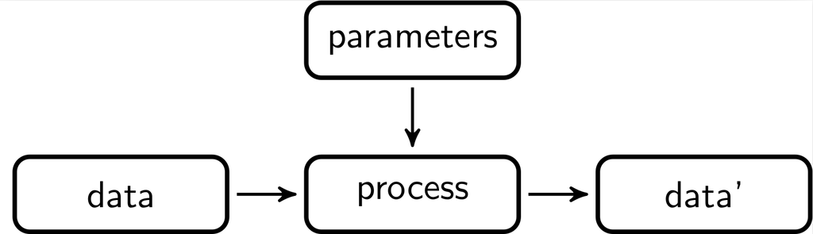

Data, process, changed data

Here, some input data is processed by some procedure that is parameterized, usually by domain experts. The output data is again input for a next step.

In the following two sections we discuss two methods to compare two or more versions of a data set. In the last section we demonstrate how `validate` can be combined with the lumberjack package to automate monitoring in an R script.

## 10.1 Cell counts

One of the simplest ways to compare different versions of a data set is to count how many cells have changed. In this setting it can be useful to distinguish between changes from available to missing data (and *vice versa*) and changes between data where the values change. When comparing two data sets, say the input and the output data, the total number of cells can be decomposed according to the following schema.

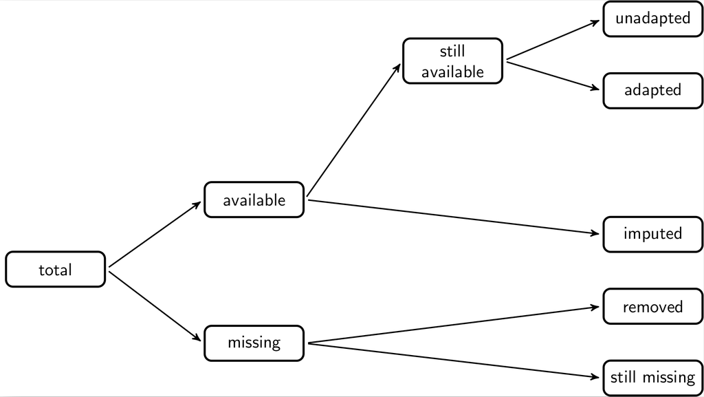

decomposition of output fields

With the `validate` package, these numbers can be computed for two or more datasets using `cells()`. As an example, we first create three versions of the `SBS2000` dataset. The first version is just the unaltered data. In the second version we replace a revenue column with it’s absolute value to ‘repair’ cases with negative revenues. In the third version, we impute cases where `turnover` is missing with the `vat` (value added tax) value, when available.

```r
library(validate)
data(SBS2000)
original <- SBS2000
version2 <- original
version2$other.rev <- abs(version2$other.rev)
version3 <- version2
version3$turnover[is.na(version3$turnover)] <- version3$vat[is.na(version3$turnover)]
```

We can now compare `version2` and `version3` to the original data set as follows.

```r
cells(input = original, cleaned = version2, imputed = version3)
```

```
## Object of class cellComparison:
##
##    cells(input = original, cleaned = version2, imputed = version3)
##
##                 input cleaned imputed
## cells             660     660     660
## available         580     580     581
## still_available   580     580     580
## unadapted         580     579     579
## adapted             0       1       1
## imputed             0       0       1
## missing            80      80      79
## still_missing      80      80      79
## removed             0       0       0
```

The `cells` function accepts an arbitrary number of `name=data frame` arguments. The names provided by the user are used as column names in the output. From the output we see that the `cleaned` data set (`version2`) and in the `imputed` data set (`version3`) have one adapted value compared to the original data. Similarly, no imputations took place in preparing the `cleaned` data set, but a single value was imputed in the `imputed` dataset.

Since each data frame is compared to the first data frame, the last column can be considered a ‘cumulative’ record of all changes that took place from beginning to end. It is also possible to print differential changes, where each data set is compared with the previous one.

```r
cells(input = original, cleaned = version2, imputed = version3
    , compare="sequential")
```

```
## Object of class cellComparison:
##
##    cells(input = original, cleaned = version2, imputed = version3, compare = "sequential")
##
##                 input cleaned imputed
## cells             660     660     660
## available         580     580     581
## still_available   580     580     580
## unadapted         580     579     580
## adapted             0       1       0
## imputed             0       0       1
## missing            80      80      79
## still_missing      80      80      79
## removed             0       0       0
```

The output of `cells()` is an array of class `cellComparison`. The most interesting about this is that `validate` comes with two plot methods for such objects. To demonstrate this, we will create two more versions of the `SBS2000` dataset.

```r
version4 <- version3
version4$turnover[is.na(version4$turnover)] <- median(version4$turnover, na.rm=TRUE)

# from kEUR to EUR
version5 <- version4
version5$staff.costs <- version5$staff.costs * 1000
```

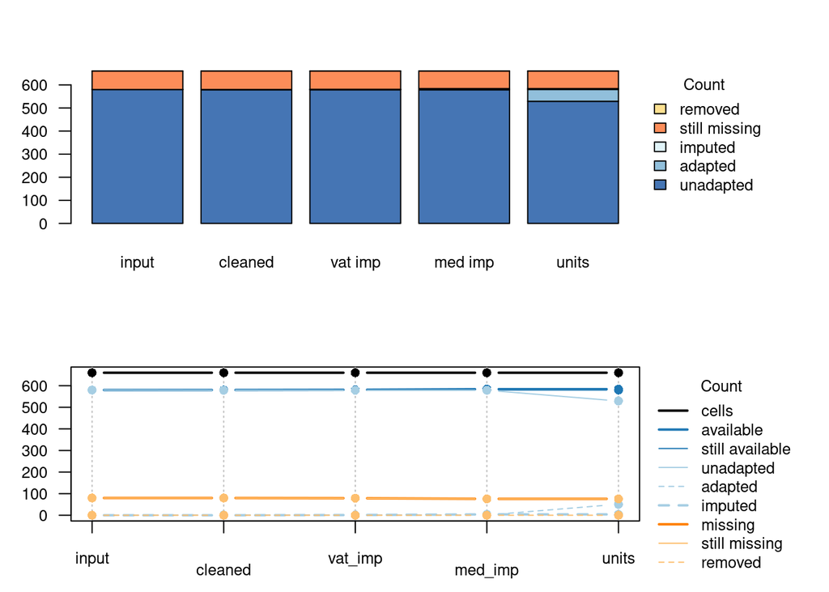

```r
out <- cells(input = original
           , cleaned = version2
           , vat_imp = version3
           , med_imp = version4
           , units   = version5)
par(mfrow=c(2,1))
barplot(out)
plot(out)
```

The bar plot and line plot convey the same information. The line plot is better when the data sets are instances resulting from a sequential process. The bar plot can be used more generally since it does not suggest a particular order.

## 10.2 Comparing rule violations

When processing data it is interesting to compare how many data validations are violated before and after a processing step. Comparing output data with input data, we can decompose the total number of validation results of the output data as follows.

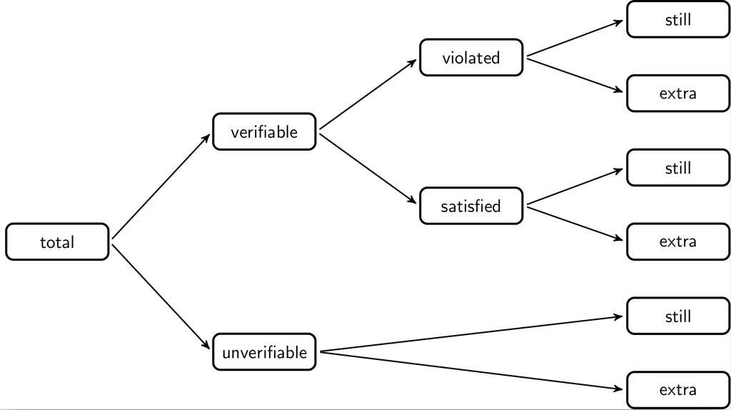

decomposition of validation output

The total number of validation results in the output data van be split into those that are verifiable (`TRUE` or `FALSE`) and those that are unverifiable (`NA`). The unverifiable cases can be split into those that were also unverifiable in the input data (still) and those that were verifiable in the input data but can now not be verified, because certain fields have been emptied. The verifiable cases can be split into those that yielded `FALSE` (violated) and those that yielded `TRUE` (satisfied). Each can be split into cases that stayed the same or changed with respect to the input data.

With `validate` the complete decomposition can be computed with `compare()`. It takes as first argument a `validator` object and two or more data sets to compare. We will use the data sets developed in the previous paragraph.

```r
rules <- validator(other.rev >= 0
                 , turnover >= 0
                 , turnover + other.rev == total.rev
)

comparison <- compare(rules
                    , input = original
                    , cleaned = version2
                    , vat_imp = version3
                    , med_imp = version4
                    , units   = version5)
comparison
```

```
## Object of class validatorComparison:
##
##    compare(x = rules, input = original, cleaned = version2, vat_imp = version3, med_imp = version4, units = version5)
##
##                     Version
## Status               input cleaned vat_imp med_imp units
##   validations          180     180     180     180   180
##   verifiable           103     103     104     108   108
##   unverifiable          77      77      76      72    72
##   still_unverifiable    77      77      76      72    72
##   new_unverifiable       0       0       0       0     0
##   satisfied             98     100     101     104   104
##   still_satisfied       98      98      98      98    98
##   new_satisfied          0       2       3       6     6
##   violated               5       3       3       4     4
##   still_violated         5       3       3       3     3
##   new_violated           0       0       0       1     1
```

By default each data set is compared to the first dataset (`input=original`). Hence the last column represents the cumulative change of all processing steps since the first data set. It is possible to investigate local differences by setting `how='sequential'`.

It is possible to plot the output for a graphical overview in two different ways: a bar plot and a line plot.

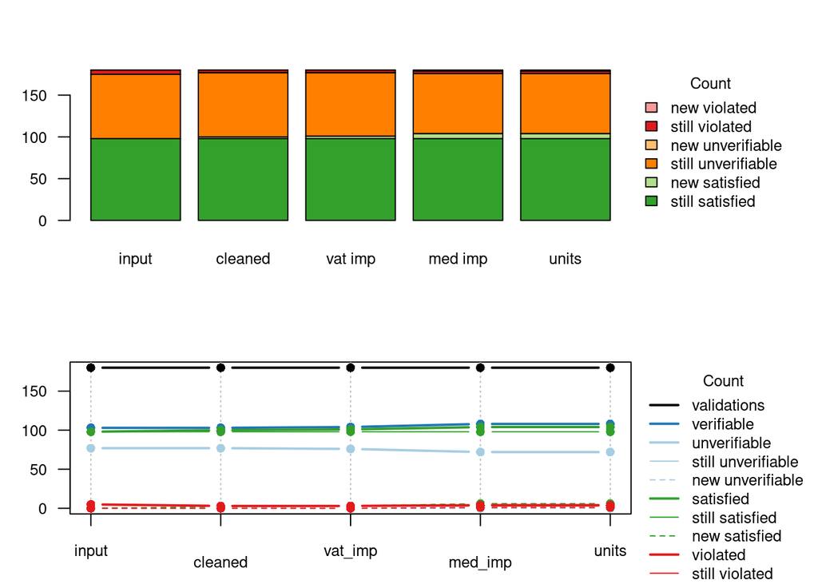

```r
par(mfrow=c(2,1))
barplot(comparison)
plot(comparison)
```

## 10.3 `validate` and `lumberjack`

The lumberjack package makes it easy to track changes in data in a user-defined way. The following example is slightly adapted from the [JSS paper](https://www.jstatsoft.org/article/view/v098i01).

We create a script that reads data, performs a few data cleaning steps and then writes the output. The script is stored in `clean_supermarkets.R` and has the following code.

```r
## Contents of clean_supermarkets.R
library(validate)

# 1. simulate reading data
data(SBS2000)
spm <- SBS2000[c("id","staff","turnover","other.rev","total.rev")]

# 2. add a logger from 'validate'
start_log(spm, logger=lbj_cells())

# 3. assume empty values should be filled with 0
spm <- transform(spm, other.rev = ifelse(is.na(other.rev),0,other.rev))

# 4. assume that negative amounts have only a sign error
spm <- transform(spm, other.rev = abs(other.rev))

# 5a. ratio estimator for staff conditional on turnover
Rhat <- with(spm, mean(staff,na.rm=TRUE)/mean(turnover,na.rm=TRUE))

# 5b. impute 'staff' variable where possible using ratio estimator
spm <- transform(spm, staff = ifelse(is.na(staff), Rhat * turnover, staff))

# 6. write output
write.csv(spm, "supermarkets_treated.csv", row.names = FALSE)
```

In the first section we do not actually read data from a data source but take a few columns from the SBS2000 data set that comes with the validate package. The data to be processed is stored in a variable called `spm`. Next, in section two, we use the `lumberjack` function `start_log()` to attach a logging object of type `lbj_cells()` to the data under scrutiny. Two things are of note here:

1. The call to `library(validate)` is necessary to be able to use `lbj_cells()`. Alternatively you can use `validate::lbj_cells()`.
2. It is not necessary to load the `lumberjack` package in this script (although it is no problem if you do).

In sections three and four, values for other revenue are imputed and then forced to be nonnegative. In section 5 a ratio model is used to impute missing staff numbers. In section 6 the output is written.

The purpose of the `lbh_cells()` logger is to record the output of `cells()` after each step. To make sure this happens, run this file using `run_file()` from the `lumberjack` package.

```r
library(lumberjack)
run_file('clean_supermarkets.R')
```

```
## Dumped a log at /tmp/RtmpsuGBc5/Rbuild3a1c390c3b28/validate/vignettes/spm_lbj_cells.csv
```

This command executed all code in `clean_supermarkets.R`, but `run_file()` also ensured that all changes in the `spm` variable were recorded and logged using `lbj_cells()`. The output is written to a `csv` file which we can read.

```r
logfile <- read.csv("spm_lbj_cells.csv")
```

The logfile variable has quite a lot of columns, so here we show just two rows.

```r
logfile[3:4,]
```

```
##   step                       time
## 3    2 2025-12-10 16:28:06.019623
## 4    3 2025-12-10 16:28:06.021258
##                                                                expression cells
## 3 spm <- transform(spm, other.rev = ifelse(is.na(other.rev),0,other.rev))   300
## 4                       spm <- transform(spm, other.rev = abs(other.rev))   300
##   available still_available unadapted adapted imputed missing still_missing
## 3       288             252       252       0      36      12            12
## 4       288             288       287       1       0      12            12
##   removed
## 3       0
## 4       0
```

Each row in the output lists the step number, a time stamp, the expression used to alter the contents of the variable under scrutiny, and all columns computed by `cells()`. Since the logger always compares two consecutive steps, these numbers are comparable to using `cells(comapare='sequential')`. For example, we see that after step four, one value was adapted compared to the state after step three. And in step three, 36 values were imputed compared to the state created by step 2. In step four, no values were imputed.

It is also interesting to follow the progression of rule violations as the `spm` dataset gets processed. This can be done with the `lbj_rules()` logger that is exported by `validate`. Since `lumberjack` allows for multiple loggers to be attached to an R object, we alter the first part of the above script as follows, and store it in `clean_supermarkets2.R`

```r
## Contents of clean_supermarkets2.R
library(validate)

#1.a simulate reading data
data(SBS2000, package="validate")
spm <- SBS2000[c("id","staff","other.rev","turnover","total.rev")]

# 1.b Create rule set
rules <- validator(staff >= 0, other.rev>=0, turnover>=0
                 , other.rev + turnover == total.rev)


# 2. add two loggers
start_log(spm, logger=lbj_cells())
start_log(spm, logger=lbj_rules(rules))

## The rest is the same as above ...
```

Running the file again using lumberjack, we now get two log files.

```r
run_file("clean_supermarkets2.R")
```

```
## Dumped a log at /tmp/RtmpsuGBc5/Rbuild3a1c390c3b28/validate/vignettes/spm_lbj_cells.csv
```

```
## Dumped a log at /tmp/RtmpsuGBc5/Rbuild3a1c390c3b28/validate/vignettes/spm_lbj_rules.csv
```

Let’s read the log file from `spm_lbj_rules.csv` and print row three and four.

```r
read.csv("spm_lbj_rules.csv")[3:4,]
```

```
##   step                       time
## 3    2 2025-12-10 16:28:06.161631
## 4    3 2025-12-10 16:28:06.176775
##                                                                expression
## 3 spm <- transform(spm, other.rev = ifelse(is.na(other.rev),0,other.rev))
## 4                       spm <- transform(spm, other.rev = abs(other.rev))
##   validations verifiable unverifiable still_unverifiable new_unverifiable
## 3         240        225           15                 15                0
## 4         240        225           15                 15                0
##   satisfied still_satisfied new_satisfied violated still_violated new_violated
## 3       218             152            66        7              5            2
## 4       220             218             2        5              5            0
```

We get the full output created by `validate::compare()`. For example we see that after step three, 66 new cases satisfy one of the checks while two new violations were introduced. The fourth step adds two new satisfied cases and no new violations. The total number of violations after four steps equals five.

Until now the logging data was written to files that were determined automatically by `lumberjack`. This is because `lumberjack` automatically dumps logging data after processing executing the file when the user has not done so explicitly. You can determine where to write the logging data by adding a `stop_log()` statement anywhere in your code (but at the end would usually make most sense).

For example, add the following line of code at the end of `clean_supermarkets2.R` to write the output of the `lbj_rules` logger to `my_output.csv`.

```r
stop_log(spm, logger="lbj_rules",file="my_output.csv")
```

The format and way in which logging data is exported is fixed by the logger. So `lbj_rules()` and `lbj_cells()` can only export to csv, and only the data we’ve seen so far. The good news is that the `lumberjack` package itself contains other loggers that may be of interest, and it is also possible to develop your own logger. So it is possible to develop loggers that export data to a database. See the [lumberjack paper](https://www.jstatsoft.org/article/view/v098i01) for a short tutorial on how to write your own logger.

# Bibliographical notes

> MPJ van der Loo and E de Jonge (2020). [Data Validation Infrastructure for R](https://www.jstatsoft.org/article/view/v097i10). *Journal of Statistical Software* 97(10)

The theory of data validation is described in the following paper.

> MPJ van der Loo, and E de Jonge (2020). [Data Validation](https://arxiv.org/abs/1912.09759). *In Wiley StatsRef: Statistics Reference Online (eds N. Balakrishnan, T. Colton, B. Everitt, W. Piegorsch, F. Ruggeri and J.L. Teugels)*.

Data validation is described in the wider context of data cleaning, in Chapter 6 of the following book.

> MPJ van der Loo and E de Jonge (2018) [Statistical Data Cleaning With Applications in R](https://www.wiley.com/en-us/Statistical+Data+Cleaning+with+Applications+in+R-p-9781118897157). *John Wiley & Sons, NY*.

The following document describes data validation in the context of European Official Statistics. It includes issues such as lifecycle management, complexity analyses and examples from practice.

> M. Zio, N. Fursova, T. Gelsema, S. Giessing, U Guarnera, J. Ptrauskiene, Q. L. Kalben, M. Scanu, K. ten Bosch, M. van der Loo, and K. Walsdorfe (2015) [Methodology for data validation](https://www.markvanderloo.eu/files/share/zio2015methodology.pdf)

The `lumberjack` package discussed in Chapter 10 is described in the following paper.

> MPJ van der Loo (2020). [Monitoring Data in R with the lumberjack package](https://www.jstatsoft.org/article/view/v098i01). *Journal of Statistical Software*, 98(1)